# Teno_salmon_pedigree

Kenyon Mobley

30/08/2023

# Citation

Sex-specific overdominance at the maturation vgll3 gene for reproductive fitness in wild Atlantic salmon

Kenyon B. Mobley1,2, Henry J. Barton1,3, Mikko Ellmén1, Annukka Ruokolainen1, Olavi Guttorm1, Hans Pieski1, Panu Orell4, Jaakko Erkinaro4, Craig R. Primmer1,5 1Organismal and Evolutionary Biology Research Program, Faculty of Biological and Environmental Sciences, PO Box 56, 00014 University of Helsinki, Finland. 2Department of Genetics, Norwegian College of Fishery Science, UiT The Arctic University of Norway, Tromsø 3Current address: Genevia Technologies Oy, Tampere, Finland. 4Natural Resources Institute Finland (Luke), PO Box 413, FI-90014 Oulu, Finland. 5Institute for Biotechnology, Helsinki Institute of Life Science (HiLIFE), 00014 University of Helsinki, Finland.

Corresponding author/data curation/author of code: Kenyon B. Mobley

# Analysis of teno salmon pedigree (2011-2019) Utsjoki, Finland

R project: Teno_salmon_pedigree.Proj license: Attribution-ShareAlike 4.0 International

## folders

```
/images #contains .png figures
/Data #contains .txt files raw and cleaned data
/Datacleanup #contains R scripts for cleaning data
/DataAnalyses #contains R scripts for statistical modeling and images
```

## Data prep: adult collection data

Calculate seaage for samples missing weight, calculate residuals for condition factor

Rscript: `Uts_adults_cleanup.R`

Dependent datafiles: `Uts_Adult_2011-2019.csv` #collection data for adults including scale data

Output data file: `UtsadultsALL_21.06.22.csv`

Column names defined

```
"sex"  #sex recorded at sampling
"ID"  #unique ID number
"year" #year collected/sampled
"date" #collection date
"date.fix" #fixed collection date format
"tag.ID" #unique anchor tag ID
"wt.kg" #total weight of fish (kg)
"length.cm" #total length of fish (cm)
"condition" #condition factor for each adult as calculated as the residuals of the length/weight regression for each sex and year
"notes.fi"  #collection notes in Finnish
"notes.en" #translated collection notes in English
"notes.KM"  #notes by author
"dead" #if the fish died
"recapture" #if fish caught previously had anchor tag
"match.ID" #ID of resampled individual
"Scale.smoltage" #scale reading of freshwater age
"scale.seaage" #scale reading of sea age
"InterpAge" #interpreted sea age at collection for each adult based on weight distribution for each sex
"Respawner" #if the individual was a respawner based on scale analysis
"respawner.info" #any notes accompanying scale information
"notes.FI" #notes on scale reading in Finnish
"notes.ENG" #notes of scale reading in English (translated)
```

## Data prep: SNP dataset

cleanup and combine SNP dataset with parentage, adult info, and sex for adults and juveniles (i.e. ‘parr’)

Rscript: `Uts_SNP_master_cleanup.R`

Dependent datafiles:

`UtsadultsALL_21.06.22.csv` #Adult collection data cleaned `2021-02-18.uts_lifehist.csv` #Data from @henryjuho of rough estimate of birth (hatch) year `UtsSNPMasterDataKM_20.11.24.csv` #Data from raw sequencing files, corrected and concatenated

Output data file: `UtsSNP_21.04.13.csv` column names defined

```
"run.name" #name of sequencing run
"run" #run number
"type" #adult /offspring(parr) sample
"year" #year collected
"BirthYear" #estimated hatch year (crude estimate of hatch year not used)
"ID" #unique ID number
"class" #age class
"class.cor" #class corrected
"sex" #genetic sex as determined by sex determining locus "SDY_ion2" Obs! this is different from "Sex"
"seq.notes" #any notes on sequencing samples/IDs
column [12...189] #SNP loci genotypes (see Aykanat et al. 2016: doi:10.1111/jfb.13149)
"AKAP11_4_fix" #reassigns genotypes in correct orientation
"vgll3mis1_fix" #reassigns genotypes in correct orientation
```

## Data prep: birthyear (i.e. hatch year) calculations

Hatch year calculations and cleanup

Rscript: `Birthyear_cleanup.R`

Dependent datafiles: `UtsSNP_21.04.13.csv` #SNP data cleaned `UtsadultsALL_21.06.22.csv` #Adult collection data cleaned

Output data file: `Uts_Birthyear_Calc_21_06_22.csv` column names defined

```
"ID" #unique ID number
"sex" #genetic sex as determined by sex determining locus "SDY_ion2"
"type" #adult /offspring(parr) sample
"class.cor" #class corrected
"year" #year collected
"BirthYear" #estimated hatch year (crude estimate of hatch year not used)
"Scale.smoltage" #scale reading of freshwater age
"scale.seaage" #scale reading of sea age
"InterpAge" #interpreted sea age at collection for each adult based on weight distribution for each sex
"Respawner" #if the individual was a respawner based on scale analysis
"respawner.info" #any notes accompanying scale information
"total.age" #total age of individual based on age class/scale readings
"total.age.int"  #total age of individual based on age class/interpreted age
"birthyear.int" #hatch year of individual based on total.age.int
```

## Data prep: Parr scale data

Utsjoki parr scale dataset, analysis for Mature male parr

Rscript: `Uts.parr.scale.data.cleanup.R`

Dependent datafiles: `parr_data_combined_22.10.21.csv` #parr scale data combined over 2012-2019

Output data file: `Uts.parr.scale_23.06.09.csv` column names defined

```
"ID" #unique ID
"year" #year collected
"OffspID.ext" #old ID
"class" #age class
"class.cor" #age class corrected
"Code" #collection location code
"new_site_code" #new collection location code
"date" #date of collection
"sample.date" #sample date
"box.info" #notes from box
"Cap.no" #notes from cap
"Cap.notes.org" #original cap notes
"Ext.notes" #notes from collection
"other.notes" #notes by author
"ID.tube"  #tube ID
"length.cm" #length in cm
"scale.reading" #age class
"scale.age" #freshwater age measured from scales
"mature.male.parr" #0 = not mature, 1 = mature
"recapture" #if the individual was recaptured
"notes.fi"  #notes from collection in Finnish
"notes.eng" #notes from collection translated in English
```

## Data prep: Parr collection and SNP data

collection data combined with SNP data

Rscript `Uts.parr.SNP.data.cleanup.R` #Utsjoki parr SNP data

Dependent datafiles: `juv.location.SNP_22.10.21.csv` #collection data for parr combined with SNP data

Output data file: `Uts.parr.SNP_23.06.09.csv`

```
"ID" #unique ID
"year" #year collected
"class" #age class
"class.cor" #age class corrected
"Code" #collection location code
"new_site_code" #new collection location code
"date" #date of collection
"run.name" #name of sequencing run
"run" #run number
"type" #adult /offspring(parr) sample
"seq.notes" #any notes on sequencing samples/IDs
"sex" #genetic sex as determined by sex determining locus "SDY_ion2"
column [17...195] #SNP loci genotypes (see Aykanat et al. 2016: doi:10.1111/jfb.13149)
```

## Data prep: default parentage analysis results

original dataset from @henryjuho and renamed, default = all age difference priors as estimated by sequoia

Rscript: `Uts_parentage_default_cleanup.R` #parentage dataset cleanup default

Dependentt data files: `UtsSNP_21.04.13.csv`#SNP data cleaned, `UtsadultsALL_21.06.22.csv` #Adult collection data cleaned, `Uts_Birthyear_Calc_21_06_22.csv` #hatch year calculations `uts_default.prior0.parents.2021-06-18.csv` #from @henryjuho (original file renamed 2021-06-18.uts_default.prior0.parents.csv)

Output data file: `Uts_parentage_default_21.06.22.csv` column names defined

```
"ID" #unique ID
"sex.off" #sex of offspring (sDY)
"type.off" #type of offspring (adult or offspring)
"class.cor.off" #class corrected of offspring
"year.off"  #year collected of offspring
"BirthYear.off" #hatch year of offspring
"birthyear.int.off" #hatch year using interpreted age of offspring
"InterpAge.x" #interpreted age (in years) of offspring
"Respawner.off"  #respawner (1 = respawner) based on scale age of offspring
"dam" #dam ID
"respawner.info.x" #respawner info of dam
"sex.dam" #sex of dam
"type.dam" #type of dam (adult or offspring)
"class.cor.dam" #Corrected age class of dam
"year.dam" #dam collection year
"BirthYear.dam" #hatch year of dam
"birthyear.int.dam"  #hatch year of dam using interpreted age
"sire" #sire ID
"InterpAge.y"  #interpreted age of dam
"Respawner.dam" #respawner (1 = respawner) based on scale age of dam
"respawner.info.y" #respawner info of sire
"sex.sire"  #sex sire
"type.sire" #type of offspring (adult or offspring)
"class.cor.sire" #class corrected sire
"year.sire" #year collected sire
"LLRdam"  #Log10-Likelihood Ratio (LLR) of this female being the mother, versus the next most likely relationship between the focal individual and this female (sequoia)
"LLRsire" #Log10-Likelihood Ratio (LLR) of this female being the father, versus the next most likely relationship between the focal individual and this father  (sequoia)
"LLRpair" #LLR for the parental pair, versus the next most likely configuration between the three individuals (with one or neither parent assigned)  (sequoia)
"OHdam" #Number of loci at which the offspring and mother are opposite homozygotes (sequoia)
"OHsire"  #Number of loci at which the offspring and father are opposite homozygotes (sequoia)
"MEpair"  #Number of Mendelian errors between the offspring and the parent pair, includes OH as well as e.g. parents being opposing homozygotes, but the offspring not being a heterozygote. The offspring being OH with both parents is counted as 2 errors. (sequoia)
"BirthYear.sire" #hatch year of sire
"birthyear.int.sire" #hatch year using interpreted age of sire
"InterpAge" #interpreted age
"Respawner.sire" #respawner (1 = respawner) based on scale age of dam
"respawner.info" respawner check/ignore
```

## Data prep: informed parentage analysis results

original dataset from @henryjuho and renamed, informed = priors for age gap of 0 and 1 for males, and 0, 1, 2 and 3 for females set to 0

Rscript: `Uts_parentage_informed_new_cleanup.R` #parentage dataset cleanup informed

Dependent data files: `UtsSNP_21.04.13.csv` #SNP data cleaned, `UtsadultsALL_21.06.22.csv` #Adult collection data cleaned, `Uts_Birthyear_Calc_21_06_22.csv` #hatch year calculations, `uts_informed.prior1.parents.2021-06-18.csv` #from @henryjuho (original file renamed 2021-06-18.uts_informed.prior1.parents.csv)

Output data file: `Uts_parentage_informed_21.06.22.csv` column names defined: same as `Uts_parentage_default_21.06.22.csv`

## Data prep: Conservative parentage analysis results

original dataset from @henryjuho and renamed, conservative = all priors less than 0.1 set to zero, to exclude all of the most improbable relationships

Rscript: `Uts_parentage_conserved.21.06.18_cleanup_new.R` #parentage dataset cleanup conservative

Dependent data files: `UtsSNP_21.04.13.csv` #SNP data cleaned, `UtsadultsALL_21.06.22.csv` #Adult collection data cleaned, `Uts_Birthyear_Calc_21_06_22.csv` #hatch year calculations, `uts_conservative.prior2.parents_2021-06-18.csv` #from @henryjuho (original file renamed 2021-06-18.uts_conservative.prior2.parents.csv)

Output data file: `Uts_parentage_conserved_21.06.22.csv` column names defined: same as `Uts_parentage_default_21.06.22.csv`

## Data prep: Calculate the number of reproductive events (cohorts) and offspring for each reproductive event for individual sires and dams using the default parentage analysis dataset

Rscript: `Uts_cohort_SNP_default_cleanup_MMPtweak.R` #parentage dataset cleanup default

Dependent data files: `UtsSNP_21.04.13.csv` #SNP data cleaned, `Uts_Birthyear_Calc_21_06_22.csv` #hatch year calculations, `Uts_parentage_default_21.06.22.csv` #default parentage data cleaned up,

Output data file: `Uts_cohort_SNP_default_11.02.22.csv` column names defined

```
"ID" #unique ID
"sex" #genetic sex as determined by sex determining locus "SDY_ion2"
"type" #adult /offspring(parr) sample
"class.cor" #age class corrected
"year" #year collected
"birthyear.int" #hatch year of individual based on total.age.int
"Scale.smoltage" #scale reading of freshwater age
"scale.seaage" #scale reading of sea age
"InterpAge" #interpreted sea age at collection for each adult based on weight distribution for each sex
"Respawner" #if the individual was a respawner based on scale analysis
"respawner.info" #any notes accompanying scale information
"firstcohort" #first reproductive event year
"seaageatmaturity" #sea age at first reproductive event
"cohort" #which reproductive event offspring belong to
"cohort.year.all" #year of reproductive event
"0+" #hatch year age class
"1+" #hatch year +1 age class
"2-3+" #hatch year +2 age class (combined for 2 and 3 age classes)
"Adult" #offspring sampled as ana adult
"n.offspring" #number of offspring
"cohort.total" #total number of reproductive events
"respawner.gen" #whether multiple reproductive events are present based on parentage analysis (iteroparous/semeparous)
"min.cohort"  #minimum number of reproductive events
"cohort.rank" #rank of reproductive event
"mature"  #for males, whether or not there spawning as a mature male parr
"AKAP11_4_fix" #AKAP11 genotypes
"c25_1441_SAC" #vgll3TOPSNP genotypes
"cohort.max"  #maximum number of reproductive events
"cohort.max.year" #year of maximum reproductive event
```

### How many offspring are assigned to dams and sires?

```
> #starting sum of offspring
> #dams
> Uts_parentage_default %>% filter(!is.na(dam)) %>% ungroup() %>% count()
     n
1 4360
> #sires
> Uts_parentage_default %>% filter(!is.na(sire)) %>% ungroup() %>% count()
     n
1 6082
```

### Check how many offspring fall into a descrete reproductive event (i.e. cohort year)

```
> Uts_default_dams_cohortyear_assignment_check %>% ungroup() %>% tally(cohort.year.correct)
# A tibble: 1 × 1
      n
  <dbl>
1  4297
> # check incorrect assignments (dams)
> Uts_default_dams_cohortyear_assignment_check %>% ungroup() %>% tally(cohort.year.incorrect)
# A tibble: 1 × 1
      n
  <dbl>
1    63
> #check correct assignments (sires)
> Uts_default_sires_cohortyear_assignment_check %>% ungroup() %>% tally(cohort.year.correct)
# A tibble: 1 × 1
      n
  <dbl>
1  6006
> # check incorrect assignments (sires)
> Uts_default_sires_cohortyear_assignment_check %>% ungroup() %>% tally(cohort.year.incorrect)
# A tibble: 1 × 1
      n
  <dbl>
1    75
```

## Data prep: Calculate the number of reproductive events (cohorts) and offspring for each reproductive event for individual sires and dams using the informed parentage analysis dataset

Rscript: `Uts_cohort_SNP_informed_cleanup_MMPtweak.R` #parentage dataset cleanup informed

Dependent data files: `UtsSNP_21.04.13.csv` #SNP data cleaned, `Uts_Birthyear_Calc_21_06_22.csv` #hatch year calculations, `Uts_parentage_informed_21.06.22.csv` #informed parentage data cleaned up

Output data file: `Uts_cohort_SNP_informed_11.02.22.csv` column names defined same as `Uts_cohort_SNP_default_11.02.22.csv`

### How many offspring are assigned to dams and sires?

```
> #starting sum of offspring
> #dams
> Uts_parentage_informed %>% filter(!is.na(dam)) %>% ungroup() %>% count()
     n
1 4283
> #sires
> Uts_parentage_informed %>% filter(!is.na(sire)) %>% ungroup() %>% count()
     n
1 6077
```

### Check how many offspring fall into a descrete reproductive event (i.e. cohort year)

```
> #check correct assignments (dams)
> Uts_informed_dams_cohortyear_assignment_check %>% ungroup() %>% tally(cohort.year.correct)
# A tibble: 1 × 1
      n
  <dbl>
1  4221
> # check incorrect assignments (dams)
> Uts_informed_dams_cohortyear_assignment_check %>% ungroup() %>% tally(cohort.year.incorrect)
# A tibble: 1 × 1
      n
  <dbl>
1    62
> #check correct assignments (sires)
> Uts_informed_sires_cohortyear_assignment_check %>% ungroup() %>% tally(cohort.year.correct)
# A tibble: 1 × 1
      n
  <dbl>
1  5998
> # check incorrect assignments (sires)
> Uts_informed_sires_cohortyear_assignment_check %>% ungroup() %>% tally(cohort.year.incorrect)
# A tibble: 1 × 1
      n
  <dbl>
1    78
```

## Data prep: Calculate the number of reproductive events (cohorts) and offspring for each reproductive event for individual sires and dams using the conservative parentage analysis dataset

Rscript: `Uts_cohort_SNP_conserved_cleanup_MMPtweak.R` #parentage dataset cleanup conservative

Dependent data files: `UtsSNP_21.04.13.csv` #SNP data cleaned, `Uts_Birthyear_Calc_21_06_22.csv` #hatch year calculations, `Uts_parentage_conserved_21.06.22.csv` #conservative parentage data cleaned up

Output data file: `Uts_cohort_SNP_cons_11.02.22.csv` column names defined same as `Uts_cohort_SNP_default_11.02.22.csv`

### How many offspring are assigned to dams and sires?

```
> #starting sum of offspring
> #dams
> Uts_parentage_cons %>% filter(!is.na(dam)) %>% ungroup() %>% count()
     n
1 4276
> #sires
> Uts_parentage_cons %>% filter(!is.na(sire)) %>% ungroup() %>% count()
     n
1 5954
```

### Check how many offspring fall into a descrete reproductive event (i.e. cohort year)

```
> #check correct assignments (dams)
> Uts_cons_dams_cohortyear_assignment_check %>% ungroup() %>% tally(cohort.year.correct)
# A tibble: 1 × 1
      n
  <dbl>
1  4214
> # check incorrect assignments (dams)
> Uts_cons_dams_cohortyear_assignment_check %>% ungroup() %>% tally(cohort.year.incorrect)
# A tibble: 1 × 1
      n
  <dbl>
1    62
> #check cocorrect assignments (sires)
> Uts_cons_sires_cohortyear_assignment_check %>% ungroup() %>% tally(cohort.year.correct)
# A tibble: 1 × 1
      n
  <dbl>
1  5876
> # check incorrect assignments (sires)
> Uts_cons_sires_cohortyear_assignment_check %>% ungroup() %>% tally(cohort.year.incorrect)
# A tibble: 1 × 1
      n
  <dbl>
1    78
```

## Data analysis: parentage analysis methods

compare assignment of offspring by the different parentage analysis methods (default, informed, conservative)

Rscript: `Uts_parentage_analysis_comparison.R`

Dependent data files: `Uts_cohort_SNP_default_11.02.22.csv` #data for reproductive events (default), `Uts_cohort_SNP_informed_11.02.22.csv` #data for reproductive events (informed), `Uts_cohort_SNP_conservative_11.02.22.csv` #data for reproductive events (conservative)

### Output: How many sires and dams as parents as adults or parr?

```
> #how many unique sires and dams as parents? (default dataset)
> Uts_cohort_SNP_default %>%
+   select(ID, sex, type, n.offspring) %>%
+   group_by(sex, type) %>%
+   summarise(count = n_distinct(ID))
# A tibble: 4 × 3
# Groups:   sex [2]
  sex   type      count
  <chr> <chr>     <int>
1 dam   Adult        77
2 dam   Offspring    90
3 sire  Adult       309
4 sire  Offspring   138
> #how many unique sires and dams as parents? (informed dataset)
> Uts_cohort_SNP_informed %>%
+   select(ID, sex, type, n.offspring) %>%
+   group_by(sex, type) %>%
+   summarise(count = n_distinct(ID))
# A tibble: 4 × 3
# Groups:   sex [2]
  sex   type      count
  <chr> <chr>     <int>
1 dam   Adult        77
2 dam   Offspring    25
3 sire  Adult       305
4 sire  Offspring   134
> #how many unique sires and dams as parents? (conserved dataset)
> Uts_cohort_SNP_conserved %>%
+   select(ID, sex, type, n.offspring) %>%
+   group_by(sex, type) %>%
+   summarise(count = n_distinct(ID))
# A tibble: 4 × 3
# Groups:   sex [2]
  sex   type      count
  <chr> <chr>     <int>
1 dam   Adult        77
2 dam   Offspring    20
3 sire  Adult       301
4 sire  Offspring    36
```

### How many offspring assigned to sires and dams as adults or parr?

```
> #how many offspring assigned to sires and dams? (default dataset)
> Uts_cohort_SNP_default %>%
+   select(ID, sex, type, n.offspring) %>%
+   group_by(sex, type) %>%
+   tally(n.offspring)
# A tibble: 4 × 3
# Groups:   sex [2]
  sex   type          n
  <chr> <chr>     <int>
1 dam   Adult      4253
2 dam   Offspring   107
3 sire  Adult      5915
4 sire  Offspring   167
> #how many offspring assigned to sires and dams? (informed dataset)
> Uts_cohort_SNP_informed %>%
+   select(ID, sex, type, n.offspring) %>%
+   group_by(sex, type) %>%
+   tally(n.offspring)
# A tibble: 4 × 3
# Groups:   sex [2]
  sex   type          n
  <chr> <chr>     <int>
1 dam   Adult      4257
2 dam   Offspring    26
3 sire  Adult      5912
4 sire  Offspring   165
> #how many offspring assigned to sires and dams? (conserved dataset)
> Uts_cohort_SNP_conserved %>%
+   select(ID, sex, type, n.offspring) %>%
+   group_by(sex, type) %>%
+   tally(n.offspring)
# A tibble: 4 × 3
# Groups:   sex [2]
  sex   type          n
  <chr> <chr>     <int>
1 dam   Adult      4255
2 dam   Offspring    21
3 sire  Adult      5912
4 sire  Offspring    42
```

### Ridgeline density plots of age at maturity

the backcalculated age at first reproduction (ageatmaturity = firstcohort - birthyear.int) for different parentage analysis methods

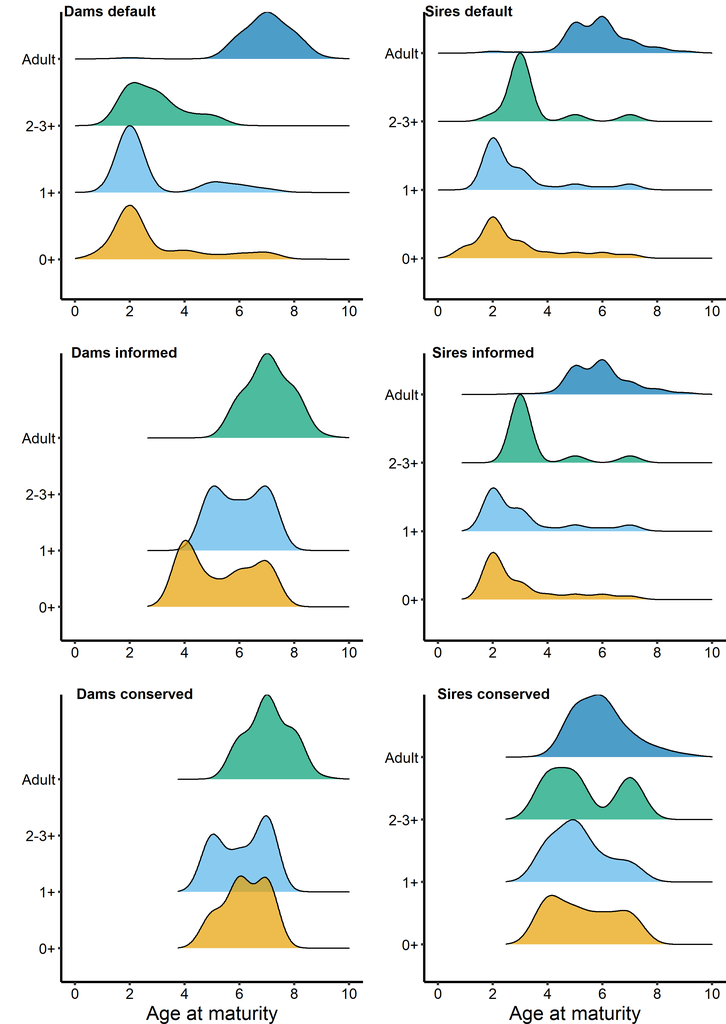

## Data analysis: Comparison of parentage methods estimating the number of offspring sired by mature male parr

Rscript: `Parentage_mathods_mature_male_parr.R`

Dependent data files: `Uts_cohort_SNP_default_11.02.22.csv` #data for reproductive events (default), `Uts_cohort_SNP_informed_11.02.22.csv` #data for reproductive events (informed), `Uts_cohort_SNP_conservative_11.02.22.csv` #data for reproductive events (conservative)

### Output: default parentage analysis

```
# count adults and offspring as adults
> Uts_cohort_SNP_default_MMP_RS_wide %>% group_by(type) %>% summarise(non_na_count = sum(!is.na(Adult)))
# A tibble: 2 × 2
  type      non_na_count
  <chr>            <int>
1 Adult              301
2 Offspring           31
> # count adults and offspring as MMP
> Uts_cohort_SNP_default_MMP_RS_wide %>% group_by(type) %>% summarise(non_na_count = sum(!is.na(MMP)))
# A tibble: 2 × 2
  type      non_na_count
  <chr>            <int>
1 Adult               14
2 Offspring          108
> # tally adults and offspring as adults
> Uts_cohort_SNP_default_MMP_RS_wide %>% group_by(type) %>% tally(Adult)
# A tibble: 2 × 2
  type          n
  <chr>     <int>
1 Adult      5896
2 Offspring    33
> # tally adults and offspring as MMP
> Uts_cohort_SNP_default_MMP_RS_wide %>% group_by(type) %>% tally(MMP)
# A tibble: 2 × 2
  type          n
  <chr>     <int>
1 Adult        19
2 Offspring   134
```

### Output: informed parentage analysis

```
> # count adults and offspring as adults
> Uts_cohort_SNP_informed_MMP_RS_wide %>% group_by(type) %>% summarise(non_na_count = sum(!is.na(Adult)))
# A tibble: 2 × 2
  type      non_na_count
  <chr>            <int>
1 Adult              301
2 Offspring           31
> # count adults and offspring as MMP
> Uts_cohort_SNP_informed_MMP_RS_wide %>% group_by(type) %>% summarise(non_na_count = sum(!is.na(MMP)))
# A tibble: 2 × 2
  type      non_na_count
  <chr>            <int>
1 Adult                7
2 Offspring          104
> # tally adults and offspring as adults
> Uts_cohort_SNP_informed_MMP_RS_wide %>% group_by(type) %>% tally(Adult)
# A tibble: 2 × 2
  type          n
  <chr>     <int>
1 Adult      5900
2 Offspring    33
> # tally adults and offspring as MMP
> Uts_cohort_SNP_informed_MMP_RS_wide %>% group_by(type) %>% tally(MMP)
# A tibble: 2 × 2
  type          n
  <chr>     <int>
1 Adult        11
2 Offspring   132
```

### Output: conserved parentage analysis

```
> # count adults and offspring as adults
> Uts_cohort_SNP_conserved_MMP_RS_wide %>% group_by(type) %>% summarise(non_na_count = sum(!is.na(Adult)))
# A tibble: 2 × 2
  type      non_na_count
  <chr>            <int>
1 Adult              301
2 Offspring           36
> # count adults and offspring as MMP
> Uts_cohort_SNP_conserved_MMP_RS_wide %>% group_by(type) %>% summarise(non_na_count = sum(!is.na(MMP)))
# A tibble: 2 × 2
  type      non_na_count
  <chr>            <int>
1 Adult                3
2 Offspring            0
> # tally adults and offspring as adults
> Uts_cohort_SNP_conserved_MMP_RS_wide %>% group_by(type) %>% tally(Adult)
# A tibble: 2 × 2
  type          n
  <chr>     <int>
1 Adult      5909
2 Offspring    42
> # tally adults and offspring as MMP
> Uts_cohort_SNP_conserved_MMP_RS_wide %>% group_by(type) %>% tally(MMP)
# A tibble: 2 × 2
  type          n
  <chr>     <int>
1 Adult         3
2 Offspring     0
```

## Data analysis: Adult dataset

basic statistics for adult dataset

Rscript: `Uts_adults_basic_stats.R`

Dependent data files: `UtsadultsALL_21.06.22.csv`

### adult statistics

```
> #How many adults? 2011 -2018
> Utsadults11_18 %>% count()
    n
1 685
> #how many for each sex?
> Utsadults11_18 %>% group_by(sex) %>% count()
# A tibble: 2 × 2
# Groups:   sex [2]
  sex       n
  <chr> <int>
1 F        93
2 M       592
> #how many are recaptures? (2 = recapture)
> Utsadults11_18 %>% group_by(sex, recapture) %>% count()
# A tibble: 4 × 3
# Groups:   sex, recapture [4]
  sex   recapture     n
  <chr>     <int> <int>
1 F             0    93
2 M             0   577
3 M             1     8
4 M             2     7
> #How many have scale smolt (i.e. freshwater) age? remove recaptures
> Utsadults11_18 %>% filter(recapture <= 1) %>% count(Scale.smoltage)
  Scale.smoltage   n
1              3 329
2              4 265
3              5  30
4              6   1
5             NA  53
> #mean scale age, remove recaptures
> Utsadults11_18 %>% filter(recapture <= 1) %>% select(sex, Scale.smoltage) %>% group_by(sex) %>% dplyr:: summarise_if(is.numeric, funs(mean(., na.rm=T), n = sum(!is.na(.)), se = sd(., na.rm=T)/sqrt(sum(!is.na(.)))))
# A tibble: 2 × 4
  sex    mean     n     se
  <chr> <dbl> <int>  <dbl>
1 F      3.52    81 0.0636
2 M      3.53   544 0.0257
> #How many have seaage age? remove recaptures
> Utsadults11_18 %>% filter(recapture <= 1) %>% count(scale.seaage)
  scale.seaage   n
1            1 466
2            2 101
3            3  78
4            4  14
5            5   8
6           NA  11
> #mean scale age, seaage remove recaptures
> Utsadults11_18 %>% filter(recapture <= 1) %>% select(sex, scale.seaage) %>% group_by(sex) %>% dplyr:: summarise_if(is.numeric, funs(mean(., na.rm=T), n = sum(!is.na(.)), se = sd(., na.rm=T)/sqrt(sum(!is.na(.)))))
# A tibble: 2 × 4
  sex    mean     n     se
  <chr> <dbl> <int>  <dbl>
1 F      2.67    89 0.103
2 M      1.31   578 0.0288
> ####make table of total individuals####
> uts.adults.ind <- Utsadults11_18 %>%
+   count(year, sex)
```

### bar graph of the number of adults collected for each sex/year

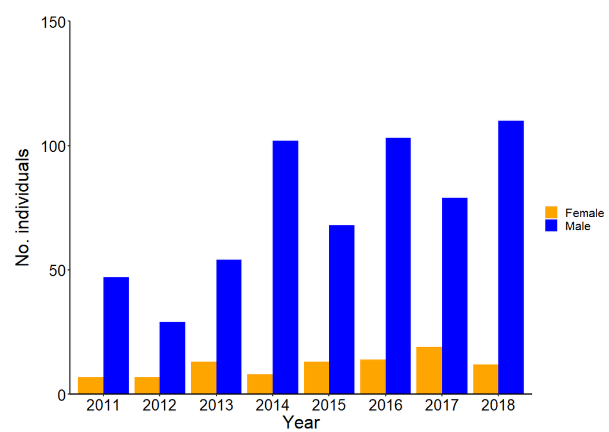

### what is the relationship between sea age and body length between the sexes?

```
> #linear regression of sea.age and length by sex
> seaageXlength <- lm(scale.seaage ~ log(length.cm) * sex, data = Utsadults_corr)
> summary(seaageXlength)

Call:
lm(formula = scale.seaage ~ log(length.cm) * sex, data = Utsadults_corr)

Residuals:
     Min       1Q   Median       3Q      Max
-0.83173 -0.20319 -0.04509  0.12496  1.84868

Coefficients:
                    Estimate Std. Error t value Pr(>|t|)
(Intercept)         -21.2446     1.0986 -19.338  < 2e-16 ***
log(length.cm)        5.3245     0.2444  21.784  < 2e-16 ***
sexM                  8.4806     1.1461   7.399 4.15e-13 ***
log(length.cm):sexM  -1.9786     0.2564  -7.716 4.42e-14 ***
---
Signif. codes:  0 ‘***’ 0.001 ‘**’ 0.01 ‘*’ 0.05 ‘.’ 0.1 ‘ ’ 1

Residual standard error: 0.3465 on 663 degrees of freedom
  (11 observations deleted due to missingness)
Multiple R-squared:  0.8416,    Adjusted R-squared:  0.8409
F-statistic:  1175 on 3 and 663 DF,  p-value: < 2.2e-16
```

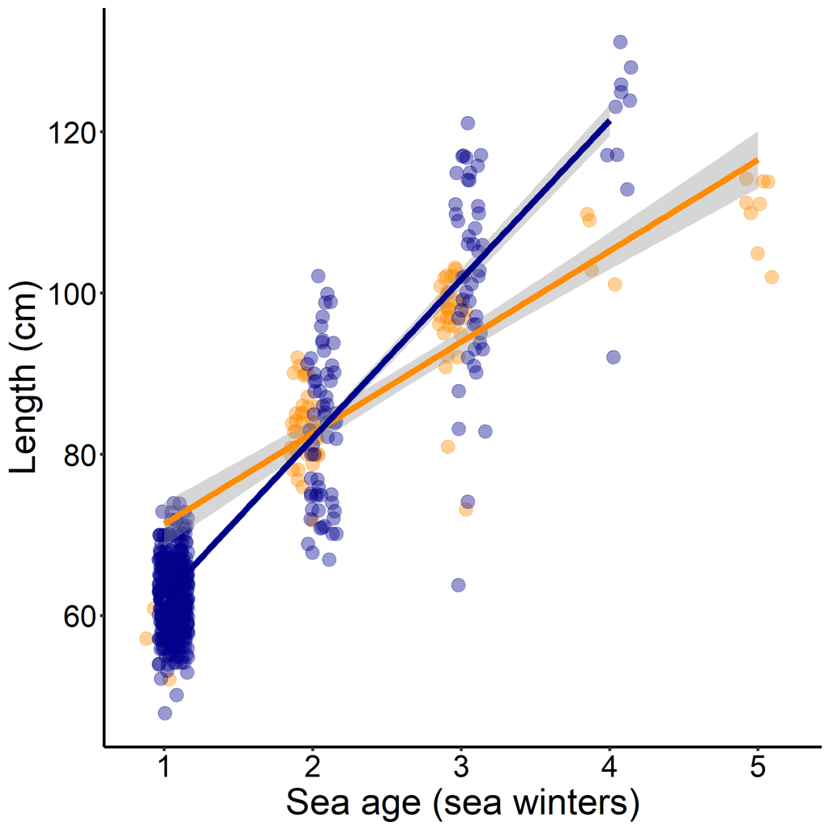

### what is the relationship between sea age and body weight between the sexes?

```
> #linear regression of sea.age and weight by sex
> seaageXweight <- lm(scale.seaage ~ log(wt.kg) * sex, data = Utsadults_corr)
> summary(seaageXweight)

Call:
lm(formula = scale.seaage ~ log(wt.kg) * sex, data = Utsadults_corr)

Residuals:
     Min       1Q   Median       3Q      Max
-0.86682 -0.21243 -0.02956  0.16709  1.95563

Coefficients:
                Estimate Std. Error t value Pr(>|t|)
(Intercept)     -0.26940    0.15600  -1.727  0.08465 .
log(wt.kg)       1.49925    0.07697  19.477  < 2e-16 ***
sexM             0.53132    0.15885   3.345  0.00087 ***
log(wt.kg):sexM -0.46461    0.08105  -5.732 1.51e-08 ***
---
Signif. codes:  0 ‘***’ 0.001 ‘**’ 0.01 ‘*’ 0.05 ‘.’ 0.1 ‘ ’ 1

Residual standard error: 0.365 on 663 degrees of freedom
  (11 observations deleted due to missingness)
Multiple R-squared:  0.8243,    Adjusted R-squared:  0.8235
F-statistic:  1037 on 3 and 663 DF,  p-value: < 2.2e-16
```

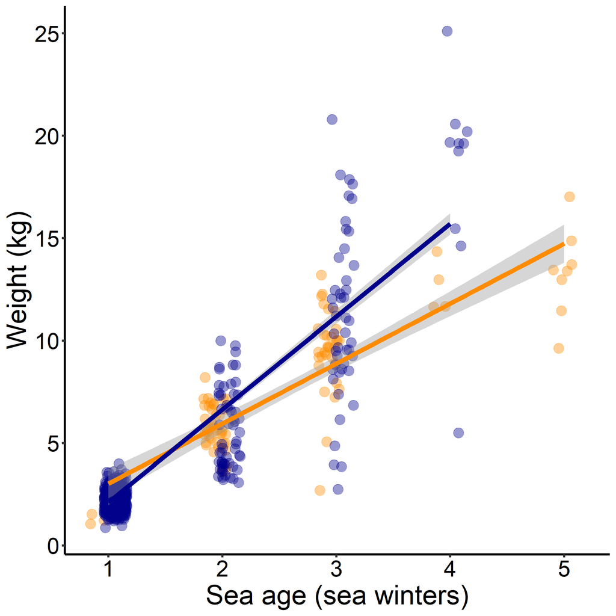

## Data visualization: parr collection data

generate a bar plot that shows the number of offspring collected in each year by age class

Rscript: `Uts.juv.collection.R`

Dependent datafiles: `juv.location.SNP_22.10.21.csv` #collection data for parr combined with SNP data

### bar graph of the number of parr collected for each year/age class

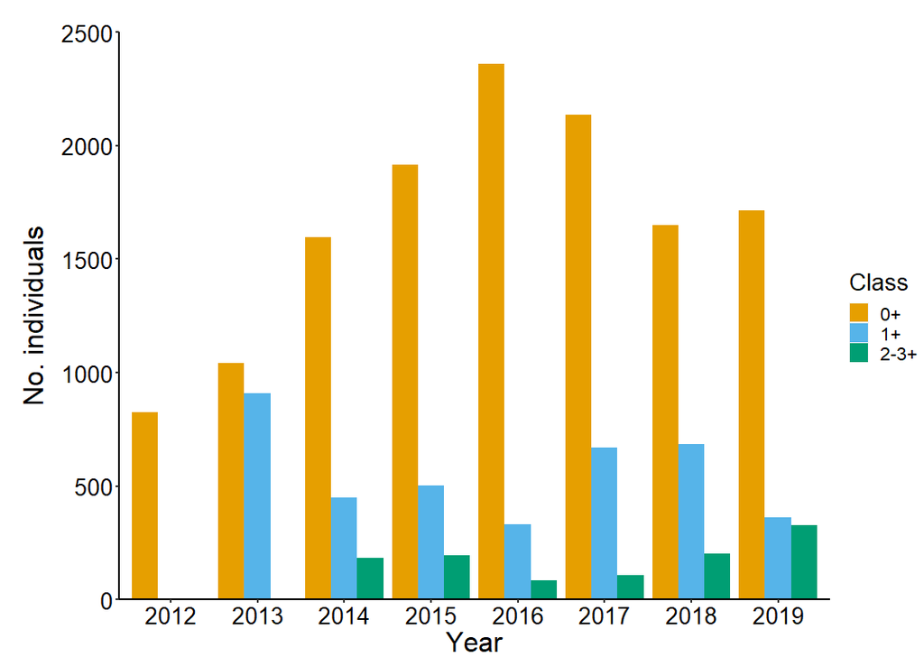

## Data analysis: Number of offspring assigned to dams/sires for conservative parentage analysis dataset

includes X2 analysis to see whether there are differences in assigment of offspring to dams/sires by age class

Rscript: `Uts.parentage age class.R` Dependent datafiles: `Uts_parentage_conserved_21.06.22.csv` #conservative parentage data cleaned up

### bar graph of the number of offspring assigned to sires and dams by age class

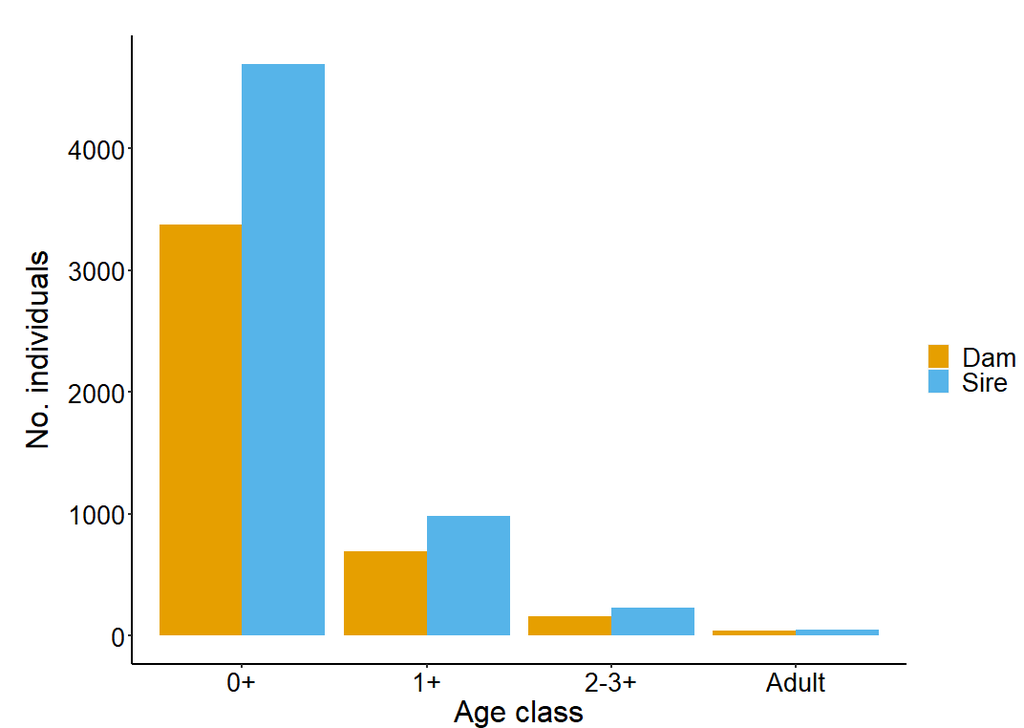

### calculate % of offspring assigned for each age class

```
Uts_Parentage_classfreq %>% group_by(sex) %>% mutate(total = sum(n)) %>% mutate(percent = n/total*100)
# A tibble: 8 × 5
# Groups:   sex [2]
  sex   class.cor.off     n total percent
  <chr> <chr>         <int> <int>   <dbl>
1 F     0+             3376  4276  79.0
2 F     1+              697  4276  16.3
3 F     2-3+            158  4276   3.70
4 F     Adult            45  4276   1.05
5 M     0+             4692  5954  78.8
6 M     1+              983  5954  16.5
7 M     2-3+            229  5954   3.85
8 M     Adult            50  5954   0.840
```

### X2 test, distribution between sires/dams over age class

```
> #chi square
> chisq.test(class.freq.wide2)

    Pearson's Chi-squared test

data:  class.freq.wide2
X-squared = 1.4352, df = 3, p-value = 0.6973
```

## Data analysis: Life history strategies

calculate life history strategies based on conservative parentage analysis dataset obs! Only adults with freshwater age and scale age. removed all dams/sires with first reproduction <2012 and >2017

Rscript: `life history strategies.R`

Dependent datafiles: `Uts_parentage_conserved_21.06.22.csv` #conservative parentage data cleaned up

```
 #how many unique LHS if sires and dams are not respawners? (scale data only)
> LHS_Norespawninfo %>% group_by(sex) %>% summarise_all(~sum(. != 0))
# A tibble: 2 × 3
  sex     LHS     n
  <chr> <int> <int>
1 dam      11     6
2 sire     11    10
> #how many unique LHS if how many sires and dams are respawners (scale data only)
> LHS_RS %>% group_by(sex) %>% summarise_all(~sum(. != 0))
# A tibble: 2 × 3
  sex     LHS     n
  <chr> <int> <int>
1 dam       5     5
2 sire      5     2
> #how many unique LHS if how many sires and dams are not respawners? (scale + parentage analysis)
> LHS_gen_Norespawninfo %>% group_by(sex) %>% summarise_all(~sum(. != 0))
# A tibble: 2 × 3
  sex   LHSall     n
  <chr>  <int> <int>
1 dam       11     7
2 sire      11    10
> #how many unique LHS if how many sires and dams are respawners (scale + parentage analysis)
> LHS_gen_RS %>% group_by(sex) %>% summarise_all(~sum(. != 0))
# A tibble: 2 × 3
  sex   LHSall     n
  <chr>  <int> <int>
1 dam       16     9
2 sire      16     8
```

### life history strategies

1. semelparous scale data only, B) iteroparous scale data only, C) semelparous scale and parentage analysis combined, D) iteroparous scale and parentage analysis combined. Notation: freshwater age – sea age, S pause between multiple mating events followed by number of years between reproductive events.

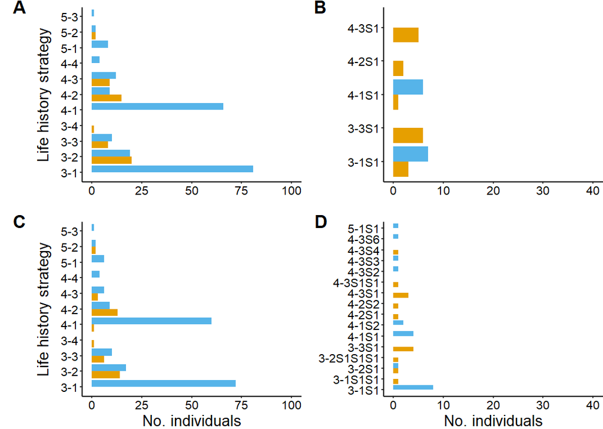

##Data analysis: mature male parr comparisons calculate the number of mature male parr collected and compare the distribution of age and size (length) between immature males and females

Rscript: `Uts.parr.scale.analysis.R`

Dependent datafiles: `Uts.parr.scale_23.06.09.csv`#cleaned parr scale data `Uts.parr.SNP_23.06.09.csv` #cleaned parr SNP data

### how many mature male parr and what are their ages?

```
> Uts.parr.scale_rmNA_SA %>% filter(mature.male.parr == 1) %>% count(mature.male.parr, scale.age)
  mature.male.parr scale.age  n
1                1         2 21
2                1         3  7
```

### How many immature and mature parr?

```
> #check if mature male parr are counted correctly (yes)
> Uts.parr.scale_sex %>% count(mature2, scale.age)
        mature2 scale.age   n
1        Female         2 313
2        Female         3  14
3 Immature male         2 279
4 Immature male         3  13
5   Mature male         2  21
6   Mature male         3   7
```

### GLM of maturity and length

```
> #glm of sex category and length
> lm.length.sex <- lm(length.cm ~ mature2, data=Uts.parr.scale_sex, type=3)
Warning message:
In lm.fit(x, y, offset = offset, singular.ok = singular.ok, ...) :
 extra argument ‘type’ will be disregarded
> #show lm results
> summary(lm.length.sex)

Call:
lm(formula = length.cm ~ mature2, data = Uts.parr.scale_sex,
    type = 3)

Residuals:
    Min      1Q  Median      3Q     Max
-4.4286 -0.9286 -0.2067  0.7714  5.0714

Coefficients:
                     Estimate Std. Error t value Pr(>|t|)
(Intercept)          10.90675    0.07380 147.787  < 2e-16 ***
mature2Immature male  0.02187    0.10756   0.203    0.839
mature2Mature male    1.12539    0.26241   4.289 2.07e-05 ***
---
Signif. codes:  0 ‘***’ 0.001 ‘**’ 0.01 ‘*’ 0.05 ‘.’ 0.1 ‘ ’ 1

Residual standard error: 1.333 on 641 degrees of freedom
  (3 observations deleted due to missingness)
Multiple R-squared:  0.02849,   Adjusted R-squared:  0.02546
F-statistic: 9.399 on 2 and 641 DF,  p-value: 9.482e-05
```

### GLM of maturity and freshwater age (scale.age)

```
> #glm of sex category and length
> lm.scale.age.sex <- lm(scale.age ~ mature2, data=Uts.parr.scale_sex, type=3)
Warning message:
In lm.fit(x, y, offset = offset, singular.ok = singular.ok, ...) :
 extra argument ‘type’ will be disregarded
> #show lm results
> summary(lm.scale.age.sex)

Call:
lm(formula = scale.age ~ mature2, data = Uts.parr.scale_sex,
    type = 3)

Residuals:
     Min       1Q   Median       3Q      Max
-0.25000 -0.04452 -0.04281 -0.04281  0.95719

Coefficients:
                     Estimate Std. Error t value Pr(>|t|)
(Intercept)          2.042813   0.012147 168.175  < 2e-16 ***
mature2Immature male 0.001707   0.017686   0.097    0.923
mature2Mature male   0.207187   0.043252   4.790 2.07e-06 ***
---
Signif. codes:  0 ‘***’ 0.001 ‘**’ 0.01 ‘*’ 0.05 ‘.’ 0.1 ‘ ’ 1

Residual standard error: 0.2197 on 644 degrees of freedom
Multiple R-squared:  0.03543,   Adjusted R-squared:  0.03244
F-statistic: 11.83 on 2 and 644 DF,  p-value: 9.013e-06
```

### ridgeline density plot of parr scale age and total length

comparison of mature male parr, immature male parr and female parr

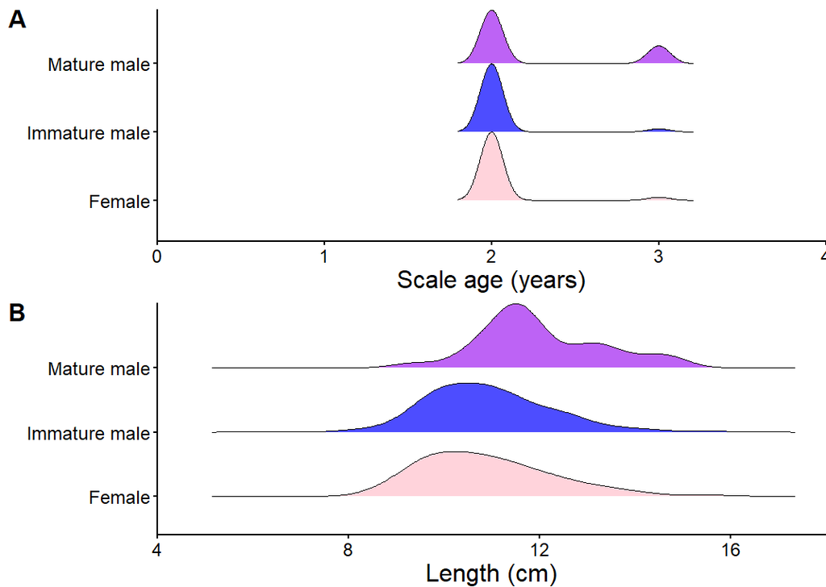

## Data analysis: Calculate the number of offspring assigned to sires and dams, and both for the conservative dataset

Parentage assignment with conservative datset, how many individuals are assigned?

Rscript: `conserved parentage assignment basic stats.R`

Dependent datafiles: `Uts_parentage_conserved_21.06.22.csv` #cleaned parentage conserved dataset

Output:

```
> #How many adults? 2011 -2018
> Utsadults11_18 %>% count()
    n
1 685
> #how many for each sex?
> Utsadults11_18 %>% group_by(sex) %>% count()
# A tibble: 2 × 2
# Groups:   sex [2]
  sex       n
  <chr> <int>
1 F        93
2 M       592
> #how many are recaptures? (2 = recapture)
> Utsadults11_18 %>% group_by(sex, recapture) %>% count()
# A tibble: 4 × 3
# Groups:   sex, recapture [4]
  sex   recapture     n
  <chr>     <int> <int>
1 F             0    93
2 M             0   577
3 M             1     8
4 M             2     7
> #How many have scale smolt (i.e. freshwater) age? remove recaptures
> Utsadults11_18 %>% filter(recapture <= 1) %>% count(Scale.smoltage)
  Scale.smoltage   n
1              3 329
2              4 265
3              5  30
4              6   1
5             NA  53
> #mean scale age, remove recaptures
> Utsadults11_18 %>% filter(recapture <= 1) %>% select(sex, Scale.smoltage) %>% group_by(sex) %>% dplyr:: summarise_if(is.numeric, funs(mean(., na.rm=T), n = sum(!is.na(.)), se = sd(., na.rm=T)/sqrt(sum(!is.na(.)))))
# A tibble: 2 × 4
  sex    mean     n     se
  <chr> <dbl> <int>  <dbl>
1 F      3.52    81 0.0636
2 M      3.53   544 0.0257
> #How many have seaage age? remove recaptures
> Utsadults11_18 %>% filter(recapture <= 1) %>% count(scale.seaage)
  scale.seaage   n
```

[output cut: 120 more lines]

```
# Groups:   sex [2]
  sex   respawner.info     n
  <chr> <chr>          <int>
1 F     1S1                3
2 F     2S1                2
3 F     3S1                8
4 M     1S1               12
5 M     2S1                1
> #calculate age ate maturity for iteroparous individuals
> Utsadults11_18matage %>% group_by(sex) %>% dplyr:: summarise_if(is.numeric, funs(mean(., na.rm=T), n = sum(!is.na(.)), se = sd(., na.rm=T)/sqrt(sum(!is.na(.)))))
# A tibble: 2 × 4
  sex    mean     n     se
  <chr> <dbl> <int>  <dbl>
1 F      2.38    13 0.241
2 M      1.08    13 0.0769
```

## Data analysis: vgll3 genotype X sea age comparions between sampled adults and parentage datasets

Using the conservative parentage analysis dataset, create glm models and graphs for vgll3 and sea age for adults and parentage data

Rscript: `Uts_conserved_seageXvgll3.R`

Dependent datafiles: `Uts_cohort_SNP_cons_11.02.22.csv` #cleaned reproductive event SNP data `UtsSNP_21.04.13.csv` #cleaned SNP data `UtsadultsALL_21.06.22.csv` #cleaned adult data

### Parentage (conservative) dataset: effect of vgll3 & sex on sea age at maturity

interactions were tested and removed because NS

```
> #Parentage dataset: vgll3 X sea age models
> mod_seaagevgll3RS <- glm(seaageatmaturity ~ sex + as.factor(c25_1441_SAC), data=Uts_conserved_total_RS)
> summary(mod_seaagevgll3RS)

Call:
glm(formula = seaageatmaturity ~ sex + as.factor(c25_1441_SAC),
    data = Uts_conserved_total_RS)

Deviance Residuals:
     Min        1Q    Median        3Q       Max
-1.91345  -0.21460  -0.21460   0.08655   2.78540

Coefficients:
                         Estimate Std. Error t value Pr(>|t|)
(Intercept)               2.03904    0.12576  16.213  < 2e-16 ***
sexsire                  -0.88166    0.10264  -8.590 7.26e-16 ***
as.factor(c25_1441_SAC)2  0.05722    0.10878   0.526    0.599
as.factor(c25_1441_SAC)3  0.75607    0.12997   5.817 1.70e-08 ***
---
Signif. codes:  0 ‘***’ 0.001 ‘**’ 0.01 ‘*’ 0.05 ‘.’ 0.1 ‘ ’ 1

(Dispersion parameter for gaussian family taken to be 0.4650747)

    Null deviance: 187.63  on 271  degrees of freedom
Residual deviance: 124.64  on 268  degrees of freedom
AIC: 569.64

Number of Fisher Scoring iterations: 2
```

### Sampled adult dataset: effect of vgll3 & sex on sea age at maturity

interactions were tested and removed because NS

```
> #vgll3 models
> mod_seaagevgll3RSadult <- glm(seaageatmaturity ~ sex.x + as.factor(c25_1441_SAC), data=Uts_adults_SNPx)
> summary(mod_seaagevgll3RSadult)

Call:
glm(formula = seaageatmaturity ~ sex.x + as.factor(c25_1441_SAC),
    data = Uts_adults_SNPx)

Deviance Residuals:
    Min       1Q   Median       3Q      Max
-1.1158  -0.1764  -0.1764  -0.1158   2.8236

Coefficients:
                         Estimate Std. Error t value Pr(>|t|)
(Intercept)               2.07271    0.07989  25.944   <2e-16 ***
sex.xM                   -0.93938    0.06728 -13.962   <2e-16 ***
as.factor(c25_1441_SAC)2  0.04308    0.05837   0.738    0.461
as.factor(c25_1441_SAC)3  0.79153    0.07444  10.633   <2e-16 ***
---
Signif. codes:  0 ‘***’ 0.001 ‘**’ 0.01 ‘*’ 0.05 ‘.’ 0.1 ‘ ’ 1

(Dispersion parameter for gaussian family taken to be 0.3554987)

    Null deviance: 386.38  on 677  degrees of freedom
Residual deviance: 239.61  on 674  degrees of freedom
AIC: 1228.9

Number of Fisher Scoring iterations: 2
```

Plot

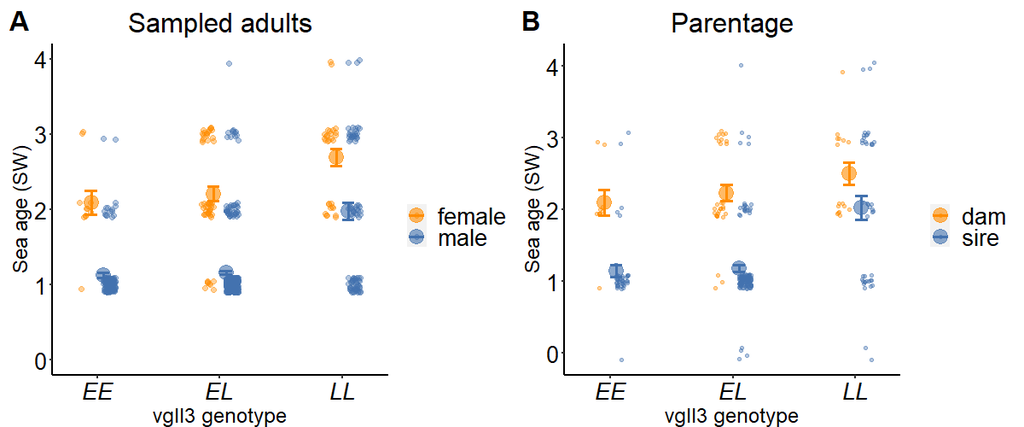

## Data analysis: glm models and graphs for the effect of sex, respawner (semelparous/iteroparous), and the maximum number of reproductive events

Using the conservative parentage analysis dataset

Rscript: `Uts_conserved_reproductive_event.R`

Dependent datafiles: `Uts_parentage_conserved_21.06.22.csv`#cleaned parentage conserved dataset

### negative binomial log link

```
 #model test, neg bionomial
> mod1_itero_off<- glm.nb(n.offspring ~ sex + cohort.max + respawner.gen, link = log, data=table.cohort.SNP.itero.conserved)
> summary(mod1_itero_off)

Call:
glm.nb(formula = n.offspring ~ sex + cohort.max + respawner.gen,
    data = table.cohort.SNP.itero.conserved, link = log, init.theta = 0.7193735096)

Deviance Residuals:
    Min       1Q   Median       3Q      Max
-1.7733  -1.1915  -0.5678   0.1503   3.9483

Coefficients:
                         Estimate Std. Error z value Pr(>|z|)
(Intercept)                2.0127     1.1125   1.809   0.0704 .
sexsire                   -0.4544     0.1840  -2.470   0.0135 *
cohort.max                 1.1986     0.5072   2.363   0.0181 *
respawner.gensemelparous   0.2144     0.5983   0.358   0.7201
---
Signif. codes:  0 ‘***’ 0.001 ‘**’ 0.01 ‘*’ 0.05 ‘.’ 0.1 ‘ ’ 1

(Dispersion parameter for Negative Binomial(0.7194) family taken to be 1)

    Null deviance: 399.32  on 271  degrees of freedom
Residual deviance: 312.73  on 268  degrees of freedom
AIC: 2294.6

Number of Fisher Scoring iterations: 1


              Theta:  0.7194
          Std. Err.:  0.0563

 2 x log-likelihood:  -2284.5660
```

#### DHARMa residual plot:

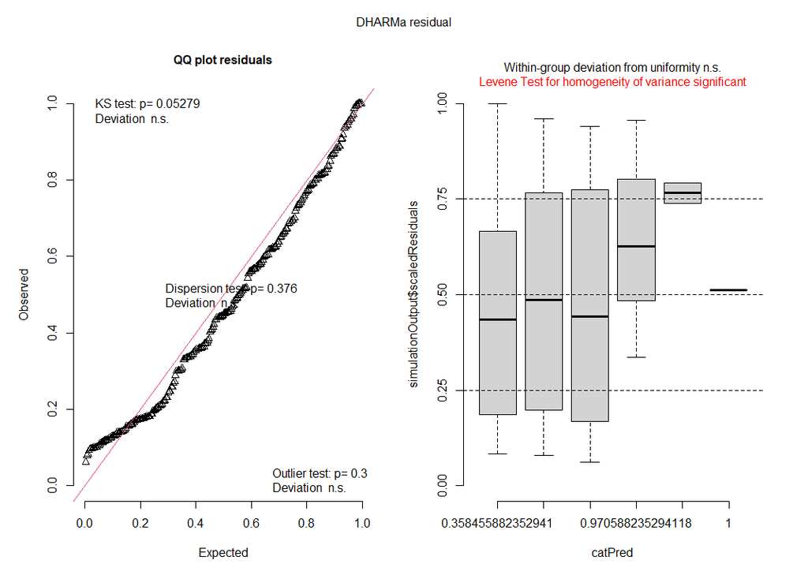

### Output: graph

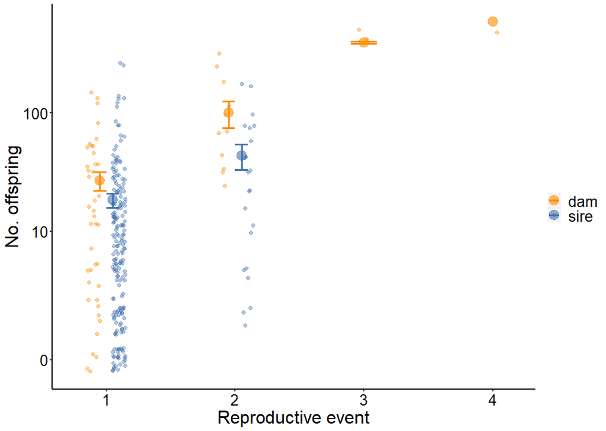

### Do iteroparous individuals increase offspring with subsequent spawnings? (request from R2)

```
> mod1_itero_ReproductiveEvent<- glm.nb(n.offspring ~ sex + cohort + c25_1441_SAC, link = log, data=Uts_conserved_offspring_ReproductiveEvent)
> summary(mod1_itero_ReproductiveEvent)

Call:
glm.nb(formula = n.offspring ~ sex + cohort + c25_1441_SAC, data = Uts_conserved_offspring_ReproductiveEvent,
    link = log, init.theta = 0.7664882239)

Deviance Residuals:
    Min       1Q   Median       3Q      Max
-2.3843  -1.2357  -0.4409   0.1485   2.3225

Coefficients:
             Estimate Std. Error z value Pr(>|z|)
(Intercept)    4.1385     0.6577   6.293 3.12e-10 ***
sexsire       -1.1633     0.2756  -4.221 2.43e-05 ***
cohort         0.5309     0.2074   2.559   0.0105 *
c25_1441_SAC  -0.3616     0.2244  -1.611   0.1071
---
Signif. codes:  0 ‘***’ 0.001 ‘**’ 0.01 ‘*’ 0.05 ‘.’ 0.1 ‘ ’ 1

(Dispersion parameter for Negative Binomial(0.7665) family taken to be 1)

    Null deviance: 116.00  on 75  degrees of freedom
Residual deviance:  87.31  on 72  degrees of freedom
AIC: 701.85

Number of Fisher Scoring iterations: 1


              Theta:  0.766
          Std. Err.:  0.115

 2 x log-likelihood:  -691.852
```

### yes, there is a signficant effect of sex and reproductive events (cohort) for iterparous individuals

slight problem with not being able to include ID as random factor

Plot: number of offspring (log) versus sex and number or reproductive events

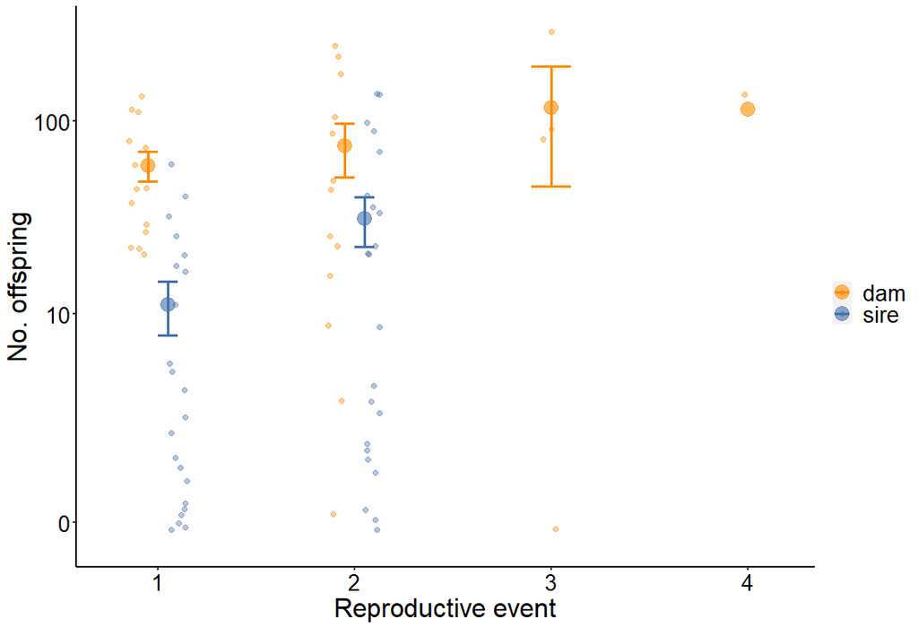

## Data analysis: Reproductive fitness with conservative parantage analysis: sires and dams separate

Using the conservative parentage analysis dataset, create glm models and graphs for reproductive success and vgll3 for sires and dams separately. Total reproductive success = offspring from all reproductive events combined, first reproductive event = time at first reproduction

Rscript: `Uts_conserved_RS_sex.R`

Dependent datafiles: `Uts_cohort_SNP_cons_11.02.22.csv` #cleaned reproductive event SNP data

### compare negative bionomial, poisson and quasipoisson models for total reproductive success for dams

Note: restricted dataset: remove individuals that have cohorts before 2012, and after 2017 Specifially testing the effect of vgll3 genotype and seaage at maturity on the number of offspring of each dam

### Negative binomial with log link vgll3 test

```
> #vgll3 additive dams negative binomial
> mod1dams <- glm.nb(n.offspring ~ factor(c25_1441_SAC) + seaageatmaturity, link = log, data=Uts_conserved_total_RS_dams)
> summary(mod1dams)

Call:
glm.nb(formula = n.offspring ~ factor(c25_1441_SAC) + seaageatmaturity,
    data = Uts_conserved_total_RS_dams, link = log, init.theta = 0.6959126218)

Deviance Residuals:
    Min       1Q   Median       3Q      Max
-2.1101  -0.9991  -0.4396   0.1933   2.2201

Coefficients:
                      Estimate Std. Error z value Pr(>|z|)
(Intercept)             2.7173     0.6818   3.985 6.74e-05 ***
factor(c25_1441_SAC)2   1.0557     0.4432   2.382   0.0172 *
factor(c25_1441_SAC)3  -0.3245     0.5008  -0.648   0.5169
seaageatmaturity        0.3470     0.2682   1.293   0.1958
---
Signif. codes:  0 ‘***’ 0.001 ‘**’ 0.01 ‘*’ 0.05 ‘.’ 0.1 ‘ ’ 1

(Dispersion parameter for Negative Binomial(0.6959) family taken to be 1)

    Null deviance: 80.219  on 55  degrees of freedom
Residual deviance: 65.825  on 52  degrees of freedom
AIC: 564.31

Number of Fisher Scoring iterations: 1


              Theta:  0.696
          Std. Err.:  0.117

 2 x log-likelihood:  -554.311
```

note: interactions were removed because of NS

#### DHARMa residual plot:

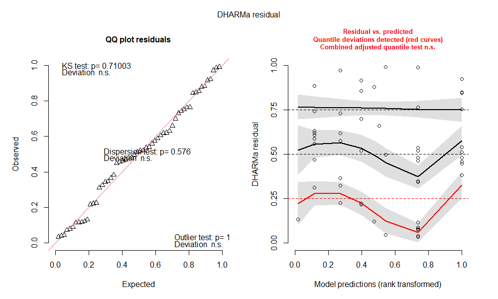

### Poisson

```
> #vgll3 additive dams poisson
> mod2dams <- glm(formula = n.offspring ~ factor(c25_1441_SAC) + seaageatmaturity, family = "poisson", data=Uts_conserved_total_RS_dams)
> summary(mod2dams)

Call:
glm(formula = n.offspring ~ factor(c25_1441_SAC) + seaageatmaturity,
    family = "poisson", data = Uts_conserved_total_RS_dams)

Deviance Residuals:
    Min       1Q   Median       3Q      Max
-12.650   -6.735   -3.492    1.457   33.950

Coefficients:
                      Estimate Std. Error z value Pr(>|z|)
(Intercept)            2.71770    0.08209  33.105  < 2e-16 ***
factor(c25_1441_SAC)2  1.00409    0.05823  17.244  < 2e-16 ***
factor(c25_1441_SAC)3 -0.35128    0.07399  -4.748 2.06e-06 ***
seaageatmaturity       0.36314    0.02764  13.139  < 2e-16 ***
---
Signif. codes:  0 ‘***’ 0.001 ‘**’ 0.01 ‘*’ 0.05 ‘.’ 0.1 ‘ ’ 1

(Dispersion parameter for poisson family taken to be 1)

    Null deviance: 6005.6  on 55  degrees of freedom
Residual deviance: 4815.8  on 52  degrees of freedom
AIC: 5101.6

Number of Fisher Scoring iterations: 6
```

#### Poisson with interactions

```
> #vgll3 additive dams poisson
> mod2dams <- glm(formula = n.offspring ~ factor(c25_1441_SAC) * seaageatmaturity, family = "poisson", data=Uts_conserved_total_RS_dams)
> summary(mod2dams)

Call:
glm(formula = n.offspring ~ factor(c25_1441_SAC) * seaageatmaturity,
    family = "poisson", data = Uts_conserved_total_RS_dams)

Deviance Residuals:
    Min       1Q   Median       3Q      Max
-12.755   -6.462   -3.384    1.707   33.732

Coefficients:
                                       Estimate Std. Error z value Pr(>|z|)
(Intercept)                             2.06044    0.23714   8.689  < 2e-16 ***
factor(c25_1441_SAC)2                   1.76371    0.24891   7.086 1.38e-12 ***
factor(c25_1441_SAC)3                   0.08786    0.30890   0.284  0.77608
seaageatmaturity                        0.65532    0.10060   6.514 7.32e-11 ***
factor(c25_1441_SAC)2:seaageatmaturity -0.33555    0.10532  -3.186  0.00144 **
factor(c25_1441_SAC)3:seaageatmaturity -0.21036    0.12345  -1.704  0.08837 .
---
Signif. codes:  0 ‘***’ 0.001 ‘**’ 0.01 ‘*’ 0.05 ‘.’ 0.1 ‘ ’ 1

(Dispersion parameter for poisson family taken to be 1)

    Null deviance: 6005.6  on 55  degrees of freedom
Residual deviance: 4804.1  on 50  degrees of freedom
AIC: 5094

Number of Fisher Scoring iterations: 6
```

#### DHARMa residual plot: note, this is the residuals of the no interactions plot, the residuals for the interactions cannot be calculated

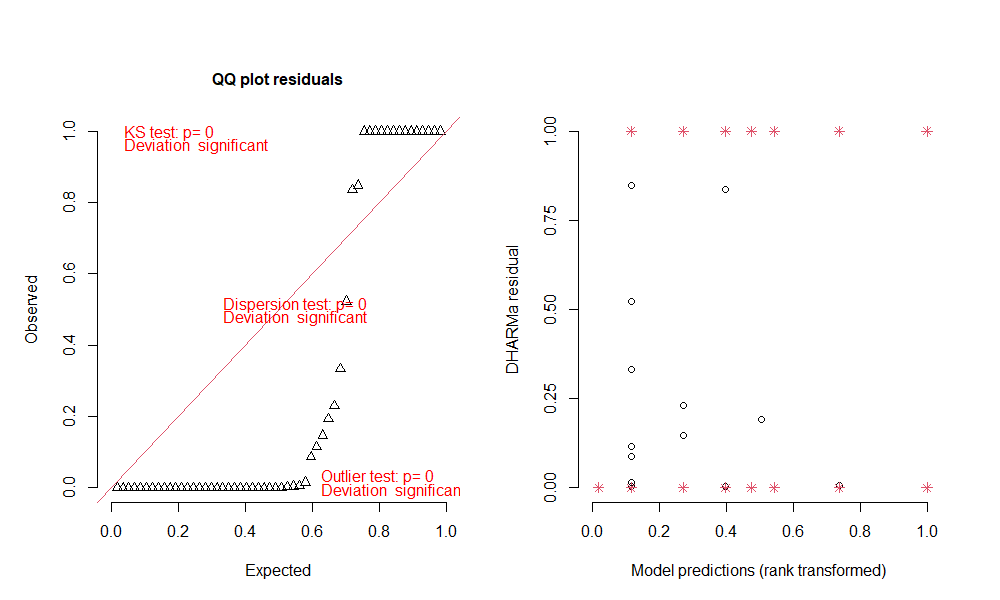

### Quasi-poisson

```
> #qvgll3 additive dams quasi-poisson
> mod3dams <- glm(formula = n.offspring ~ factor(c25_1441_SAC) + seaageatmaturity, family = "quasipoisson", data=Uts_conserved_total_RS_dams)
> summary(mod3dams)

Call:
glm(formula = n.offspring ~ factor(c25_1441_SAC) + seaageatmaturity,
    family = "quasipoisson", data = Uts_conserved_total_RS_dams)

Deviance Residuals:
    Min       1Q   Median       3Q      Max
-12.650   -6.735   -3.492    1.457   33.950

Coefficients:
                      Estimate Std. Error t value Pr(>|t|)
(Intercept)             2.7177     0.9366   2.902  0.00543 **
factor(c25_1441_SAC)2   1.0041     0.6643   1.511  0.13672
factor(c25_1441_SAC)3  -0.3513     0.8441  -0.416  0.67901
seaageatmaturity        0.3631     0.3153   1.152  0.25471
---
Signif. codes:  0 ‘***’ 0.001 ‘**’ 0.01 ‘*’ 0.05 ‘.’ 0.1 ‘ ’ 1

(Dispersion parameter for quasipoisson family taken to be 130.1536)

    Null deviance: 6005.6  on 55  degrees of freedom
Residual deviance: 4815.8  on 52  degrees of freedom
AIC: NA

Number of Fisher Scoring iterations: 6
```

no interactions with quasipoisson #### DHARMa residual plot: DHARMa cannot generate residuals, AIC cannot be computed. #### Based on these results, negative binomial has the lowest AIC score, predictable residuals and will be used for dam models

### compare negative bionomial, poisson and quasipoisson models for total reproductive success for sires

Note: restricted dataset: remove individuals that have cohorts before 2012, and after 2017 Specifially testing the effect of vgll3 genotype and seaage at maturity on the number of offspring of each sire

### Negative Binomial with log link

```
> #vgll3 additive sires NB
> mod1sires<- glm.nb(n.offspring ~ factor(c25_1441_SAC) + seaageatmaturity, link = log, data=Uts_conserved_total_RS_sires)
> summary(mod1sires)

Call:
glm.nb(formula = n.offspring ~ factor(c25_1441_SAC) + seaageatmaturity,
    data = Uts_conserved_total_RS_sires, link = log, init.theta = 0.7721700353)

Deviance Residuals:
    Min       1Q   Median       3Q      Max
-2.0756  -1.1690  -0.6110   0.1057   3.3147

Coefficients:
                      Estimate Std. Error z value Pr(>|z|)
(Intercept)             1.9360     0.2235   8.664  < 2e-16 ***
factor(c25_1441_SAC)2   0.2174     0.2072   1.049    0.294
factor(c25_1441_SAC)3   0.2618     0.2721   0.962    0.336
seaageatmaturity        0.6250     0.1146   5.454 4.93e-08 ***
---
Signif. codes:  0 ‘***’ 0.001 ‘**’ 0.01 ‘*’ 0.05 ‘.’ 0.1 ‘ ’ 1

(Dispersion parameter for Negative Binomial(0.7722) family taken to be 1)

    Null deviance: 293.04  on 215  degrees of freedom
Residual deviance: 244.35  on 212  degrees of freedom
AIC: 1723.7

Number of Fisher Scoring iterations: 1


              Theta:  0.7722
          Std. Err.:  0.0692

 2 x log-likelihood:  -1713.6820
```

no interactions

#### DHARMa residual plot: negative binomial with log link

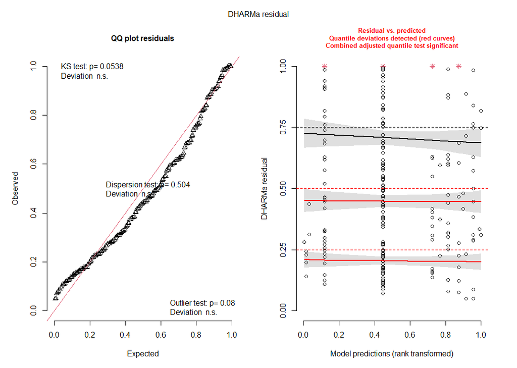

### poisson

```
 #vgll3 additive sires poisson
> mod2sires <- glm(formula = n.offspring ~ factor(c25_1441_SAC) + seaageatmaturity, family = "poisson", data=Uts_conserved_total_RS_sires)
> summary(mod2sires)

Call:
glm(formula = n.offspring ~ factor(c25_1441_SAC) + seaageatmaturity,
    family = "poisson", data = Uts_conserved_total_RS_sires)

Deviance Residuals:
     Min        1Q    Median        3Q       Max
-10.3078   -4.2871   -2.6146    0.4492   22.4114

Coefficients:
                      Estimate Std. Error z value Pr(>|z|)
(Intercept)            1.97076    0.04683  42.081  < 2e-16 ***
factor(c25_1441_SAC)2  0.27835    0.04573   6.086 1.16e-09 ***
factor(c25_1441_SAC)3  0.45554    0.05214   8.737  < 2e-16 ***
seaageatmaturity       0.54580    0.01663  32.818  < 2e-16 ***
---
Signif. codes:  0 ‘***’ 0.001 ‘**’ 0.01 ‘*’ 0.05 ‘.’ 0.1 ‘ ’ 1

(Dispersion parameter for poisson family taken to be 1)

    Null deviance: 8124.0  on 215  degrees of freedom
Residual deviance: 6406.2  on 212  degrees of freedom
AIC: 7286.9

Number of Fisher Scoring iterations: 6
```

with interactions

```
> #vgll3 additive sires poisson
> mod2sires <- glm(formula = n.offspring ~ factor(c25_1441_SAC) * seaageatmaturity, family = "poisson", data=Uts_conserved_total_RS_sires)
> summary(mod2sires)

Call:
glm(formula = n.offspring ~ factor(c25_1441_SAC) * seaageatmaturity,
    family = "poisson", data = Uts_conserved_total_RS_sires)

Deviance Residuals:
     Min        1Q    Median        3Q       Max
-10.4646   -4.4571   -2.4928    0.4789   22.8990

Coefficients:
                                       Estimate Std. Error z value Pr(>|z|)
(Intercept)                             2.38481    0.09418  25.322  < 2e-16 ***
factor(c25_1441_SAC)2                  -0.08030    0.10285  -0.781 0.434960
factor(c25_1441_SAC)3                  -0.18017    0.11774  -1.530 0.125950
seaageatmaturity                        0.22073    0.07003   3.152 0.001622 **
factor(c25_1441_SAC)2:seaageatmaturity  0.28603    0.07461   3.834 0.000126 ***
factor(c25_1441_SAC)3:seaageatmaturity  0.40831    0.07422   5.501 3.77e-08 ***
---
Signif. codes:  0 ‘***’ 0.001 ‘**’ 0.01 ‘*’ 0.05 ‘.’ 0.1 ‘ ’ 1

(Dispersion parameter for poisson family taken to be 1)

    Null deviance: 8124.0  on 215  degrees of freedom
Residual deviance: 6367.6  on 210  degrees of freedom
AIC: 7252.3

Number of Fisher Scoring iterations: 6
```

#### DHARMa residual plot: note, this is the residuals of the no interactions plot, the residuals for the interactions cannot be calculated

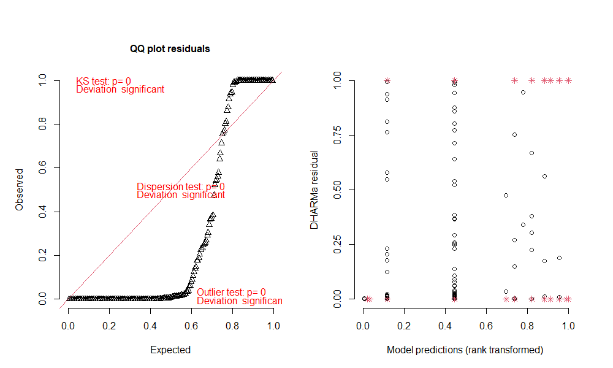

### Quasi-poisson

```
> #qvgll3 additive sires quasi-poisson
> mod3sires <- glm(formula = n.offspring ~ factor(c25_1441_SAC) + seaageatmaturity, family = "quasipoisson", data=Uts_conserved_total_RS_sires)
> summary(mod3sires)

Call:
glm(formula = n.offspring ~ factor(c25_1441_SAC) + seaageatmaturity,
    family = "quasipoisson", data = Uts_conserved_total_RS_sires)

Deviance Residuals:
     Min        1Q    Median        3Q       Max
-10.3078   -4.2871   -2.6146    0.4492   22.4114

Coefficients:
                      Estimate Std. Error t value Pr(>|t|)
(Intercept)             1.9708     0.3173   6.211 2.74e-09 ***
factor(c25_1441_SAC)2   0.2784     0.3099   0.898    0.370
factor(c25_1441_SAC)3   0.4555     0.3533   1.290    0.199
seaageatmaturity        0.5458     0.1127   4.844 2.45e-06 ***
---
Signif. codes:  0 ‘***’ 0.001 ‘**’ 0.01 ‘*’ 0.05 ‘.’ 0.1 ‘ ’ 1

(Dispersion parameter for quasipoisson family taken to be 45.90119)

    Null deviance: 8124.0  on 215  degrees of freedom
Residual deviance: 6406.2  on 212  degrees of freedom
AIC: NA

Number of Fisher Scoring iterations: 6
```

no interactions with quasipoisson #### DHARMa residual plot: DHARMa cannot generate residuals, AIC cannot be computed. #### Based on these results, negative binomial has the lowest AIC score, predictable residuals and will be used for sire models

### Results of negative binomial GLM with log link for dams for the first reproductive event

```
> mod1dams_1C<- glm.nb(n.offspring ~ factor(c25_1441_SAC) + seaageatmaturity, link = log, data=Uts_conserved_total_RS_dams_1C )
> summary(mod1dams_1C)

Call:
glm.nb(formula = n.offspring ~ factor(c25_1441_SAC) + seaageatmaturity,
    data = Uts_conserved_total_RS_dams_1C, link = log, init.theta = 1.009445309)

Deviance Residuals:
    Min       1Q   Median       3Q      Max
-2.1655  -1.1335  -0.1555   0.1825   1.7465

Coefficients:
                      Estimate Std. Error z value Pr(>|z|)
(Intercept)             2.4222     0.5708   4.243  2.2e-05 ***
factor(c25_1441_SAC)2   0.3131     0.3705   0.845   0.3980
factor(c25_1441_SAC)3  -0.4610     0.4189  -1.101   0.2711
seaageatmaturity        0.4628     0.2246   2.061   0.0393 *
---
Signif. codes:  0 ‘***’ 0.001 ‘**’ 0.01 ‘*’ 0.05 ‘.’ 0.1 ‘ ’ 1

(Dispersion parameter for Negative Binomial(1.0094) family taken to be 1)

    Null deviance: 72.673  on 55  degrees of freedom
Residual deviance: 63.317  on 52  degrees of freedom
AIC: 517.58

Number of Fisher Scoring iterations: 1


              Theta:  1.009
          Std. Err.:  0.182

 2 x log-likelihood:  -507.578
> #simulate residuals
> resmod1dams_1C <- simulateResiduals(mod1dams_1C, plot = T)
```

#### DHARMa residual plot: negative binomial with log link

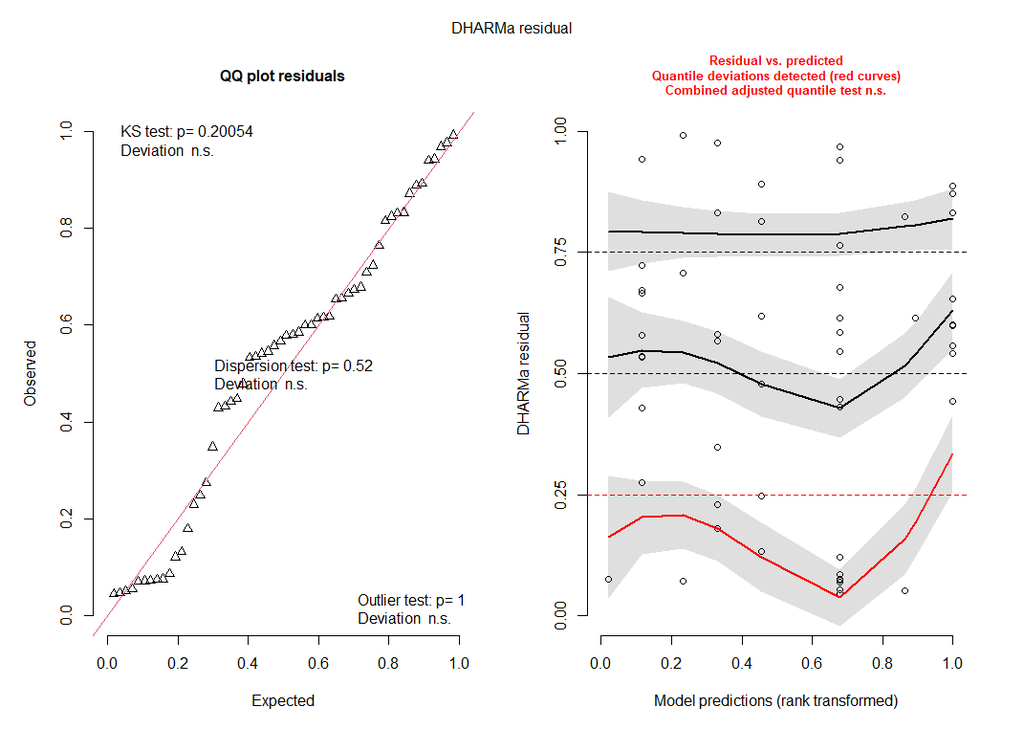

### Results of negative binomial GLM with log link for sires for the first reproductive event

```
> #model test, neg bionomial
> mod1sires_1C<- glm.nb(n.offspring ~ factor(c25_1441_SAC) + seaageatmaturity, link = log, data=Uts_conserved_total_RS_sires_1C )
> summary(mod1sires_1C)

Call:
glm.nb(formula = n.offspring ~ factor(c25_1441_SAC) + seaageatmaturity,
    data = Uts_conserved_total_RS_sires_1C, link = log, init.theta = 0.8897868593)

Deviance Residuals:
    Min       1Q   Median       3Q      Max
-2.2606  -1.0932  -0.4851   0.2034   3.3064

Coefficients:
                      Estimate Std. Error z value Pr(>|z|)
(Intercept)            1.39772    0.21133   6.614 3.74e-11 ***
factor(c25_1441_SAC)2  0.24441    0.19574   1.249    0.212
factor(c25_1441_SAC)3  0.09652    0.25723   0.375    0.707
seaageatmaturity       0.85098    0.10785   7.891 3.01e-15 ***
---
Signif. codes:  0 ‘***’ 0.001 ‘**’ 0.01 ‘*’ 0.05 ‘.’ 0.1 ‘ ’ 1

(Dispersion parameter for Negative Binomial(0.8898) family taken to be 1)

    Null deviance: 326.28  on 215  degrees of freedom
Residual deviance: 238.18  on 212  degrees of freedom
AIC: 1626.2

Number of Fisher Scoring iterations: 1


              Theta:  0.8898
          Std. Err.:  0.0829

 2 x log-likelihood:  -1616.1600
```

#### DHARMa residual plot: negative binomial with log link

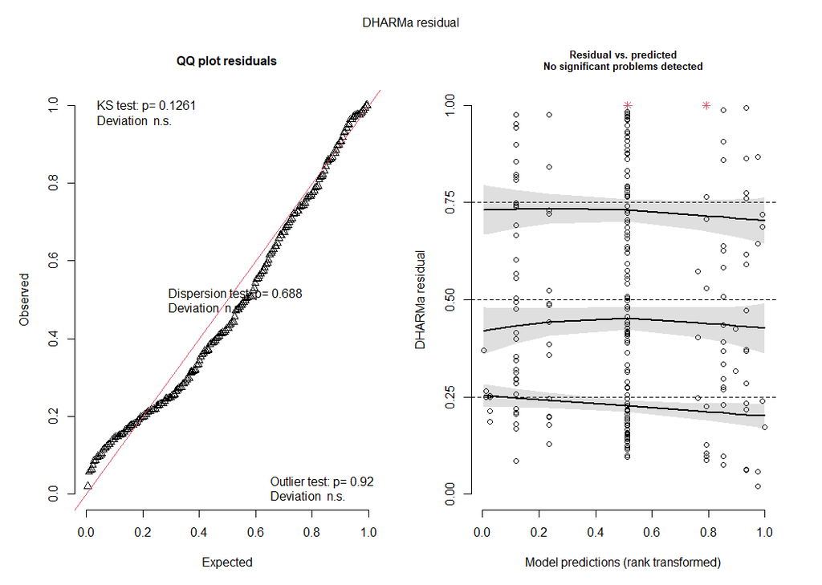

### Output: Combined graph

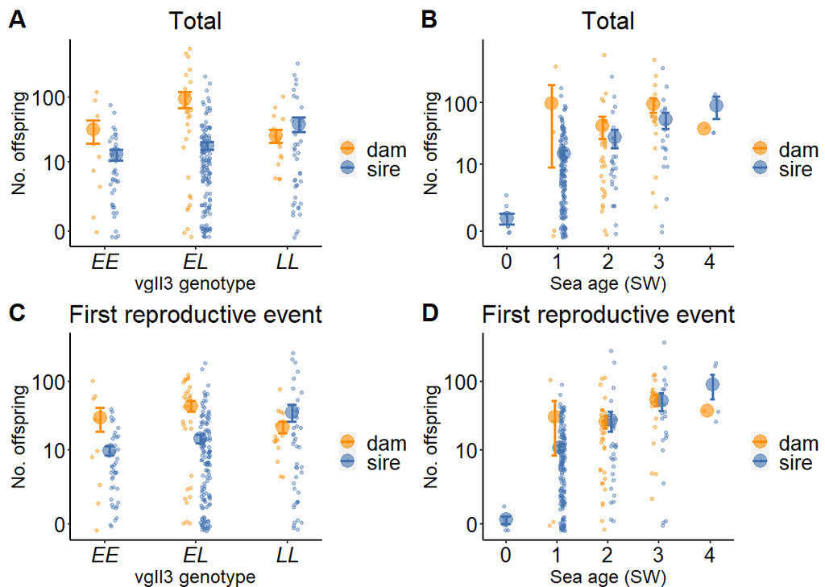

## Data analysis: repeatspawning (semelparous/iteroparous) reproductive success

Reproductive fitness with conservative parentage analysis Using the conservative parentage analysis dataset, create glm models and graphs for total reproductive success and reproductive success for the first reproduction for sires and dams separately iteroparous and semelparous individuals

Rscript: `Uts_conserved_RS_iteroparous.R`

Dependent datafiles: `Uts_cohort_SNP_cons_11.02.22.csv` #cleaned reproductive event SNP data

### Model results: dams

```
> #model test, neg bionomial
> mod1_dams_RS<- glm.nb(n.offspring ~ respawner.gen + factor(c25_1441_SAC) + seaageatmaturity, link = log, data=table.Uts_cohort_SNP_conserved_1C_dams)
> summary(mod1_dams_RS)

Call:
glm.nb(formula = n.offspring ~ respawner.gen + factor(c25_1441_SAC) +
    seaageatmaturity, data = table.Uts_cohort_SNP_conserved_1C_dams,
    link = log, init.theta = 1.066058372)

Deviance Residuals:
    Min       1Q   Median       3Q      Max
-2.1244  -1.0964  -0.2192   0.2665   1.8779

Coefficients:
                         Estimate Std. Error z value Pr(>|z|)
(Intercept)                3.0555     0.6928   4.411 1.03e-05 ***
respawner.gensemelparous  -0.5663     0.3185  -1.778   0.0754 .
factor(c25_1441_SAC)2      0.1823     0.3654   0.499   0.6178
factor(c25_1441_SAC)3     -0.5000     0.4089  -1.223   0.2215
seaageatmaturity           0.3938     0.2269   1.736   0.0826 .
---
Signif. codes:  0 ‘***’ 0.001 ‘**’ 0.01 ‘*’ 0.05 ‘.’ 0.1 ‘ ’ 1

(Dispersion parameter for Negative Binomial(1.0661) family taken to be 1)

    Null deviance: 76.441  on 55  degrees of freedom
Residual deviance: 63.055  on 51  degrees of freedom
AIC: 516.15

Number of Fisher Scoring iterations: 1


              Theta:  1.066
          Std. Err.:  0.194

 2 x log-likelihood:  -504.151
```

#### DHARMa residual plot: negative binomial with log link

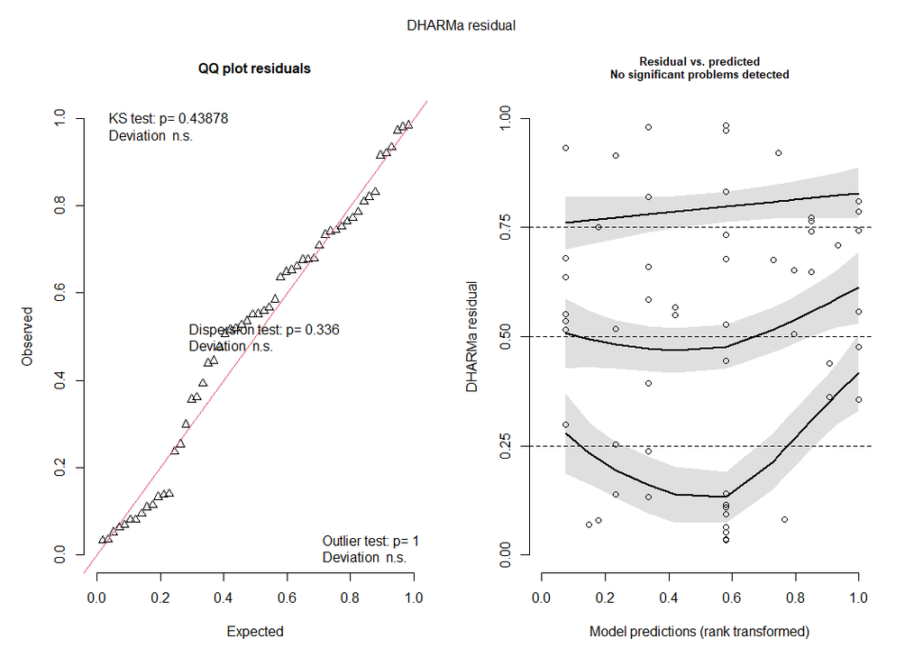

### Model results: sires

```
 pseaage.conserved_1C_sires_seaage
> #model test, neg bionomial
> mod1_sires_RS<- glm.nb(n.offspring ~ respawner.gen + factor(c25_1441_SAC) + seaageatmaturity, link = log, data=table.Uts_cohort_SNP_conserved_1C_sires)
> summary(mod1_sires_RS)

Call:
glm.nb(formula = n.offspring ~ respawner.gen + factor(c25_1441_SAC) +
    seaageatmaturity, data = table.Uts_cohort_SNP_conserved_1C_sires,
    link = log, init.theta = 0.8945278587)

Deviance Residuals:
    Min       1Q   Median       3Q      Max
-2.2642  -1.0942  -0.4948   0.1762   3.2397

Coefficients:
                         Estimate Std. Error z value Pr(>|z|)
(Intercept)                1.1444     0.3040   3.764 0.000167 ***
respawner.gensemelparous   0.2938     0.2495   1.178 0.238963
factor(c25_1441_SAC)2      0.2490     0.1953   1.275 0.202333
factor(c25_1441_SAC)3      0.1235     0.2570   0.480 0.630983
seaageatmaturity           0.8344     0.1079   7.733 1.05e-14 ***
---
Signif. codes:  0 ‘***’ 0.001 ‘**’ 0.01 ‘*’ 0.05 ‘.’ 0.1 ‘ ’ 1

(Dispersion parameter for Negative Binomial(0.8945) family taken to be 1)

    Null deviance: 327.87  on 215  degrees of freedom
Residual deviance: 238.03  on 211  degrees of freedom
AIC: 1626.9

Number of Fisher Scoring iterations: 1


              Theta:  0.8945
          Std. Err.:  0.0834

 2 x log-likelihood:  -1614.8770
```

#### DHARMa residual plot: negative binomial with log link

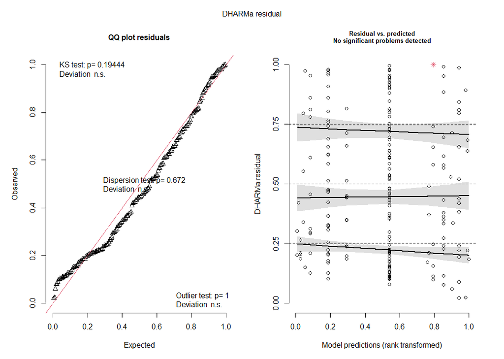

#### output: Combined graph

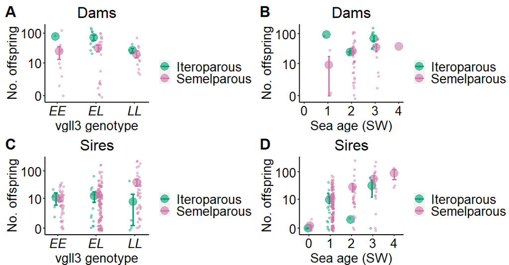

## Data analysis: additive and dominance models of vgll3 and sea age on reproductive success.

```
Additive  effects were coded as vgll3*EE = 1, vgll3*EL = 0, vgll3*LL = −1, Dominance  effects were coded as vgll3*EE = 0, vgll3*EL = 1, vgll3*LL = 0.
```

Rscript: `Uts_reprod_fitness_dominance_models.R`

Dependent datafiles: `Uts_parentage_conserved_21.06.22.csv`#cleaned parentage conserved dataset

### Dams total reproductive success

```
> #dams
> mod1dams_dom <- glm.nb(n.offspring ~ vgll3_additive + vgll3_dominance + seaageatmaturity, link = log, data=Uts_conserved_total_RS_dom_dams)
> summary(mod1dams_dom)

Call:
glm.nb(formula = n.offspring ~ vgll3_additive + vgll3_dominance +
    seaageatmaturity, data = Uts_conserved_total_RS_dom_dams,
    link = log, init.theta = 0.6959126218)

Deviance Residuals:
    Min       1Q   Median       3Q      Max
-2.1101  -0.9991  -0.4396   0.1933   2.2201

Coefficients:
                 Estimate Std. Error z value Pr(>|z|)
(Intercept)        2.5550     0.6643   3.846 0.000120 ***
vgll3_additive     0.1623     0.2504   0.648 0.516944
vgll3_dominance    1.2180     0.3292   3.700 0.000216 ***
seaageatmaturity   0.3470     0.2682   1.293 0.195845
---
Signif. codes:  0 ‘***’ 0.001 ‘**’ 0.01 ‘*’ 0.05 ‘.’ 0.1 ‘ ’ 1

(Dispersion parameter for Negative Binomial(0.6959) family taken to be 1)

    Null deviance: 80.219  on 55  degrees of freedom
Residual deviance: 65.825  on 52  degrees of freedom
AIC: 564.31

Number of Fisher Scoring iterations: 1


              Theta:  0.696
          Std. Err.:  0.117

 2 x log-likelihood:  -554.311
```

#### DHARMa residual plot: negative binomial with log link

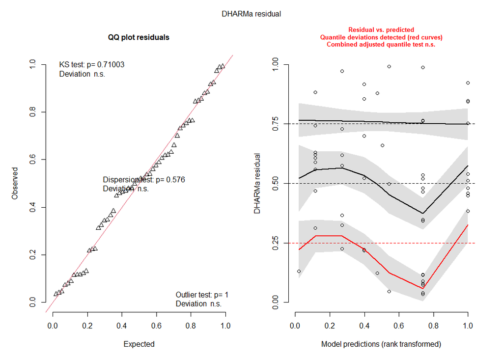

### Sires total reproductive success

```
> #vgll3 additive sires NB
> mod1sires_dom <- glm.nb(n.offspring ~ vgll3_additive + vgll3_dominance + seaageatmaturity, link = log, data=Uts_conserved_total_RS_dom_sires)
> summary(mod1sires_dom)

Call:
glm.nb(formula = n.offspring ~ vgll3_additive + vgll3_dominance +
    seaageatmaturity, data = Uts_conserved_total_RS_dom_sires,
    link = log, init.theta = 0.7721700353)

Deviance Residuals:
    Min       1Q   Median       3Q      Max
-2.0756  -1.1690  -0.6110   0.1057   3.3147

Coefficients:
                 Estimate Std. Error z value Pr(>|z|)
(Intercept)       2.06694    0.22212   9.306  < 2e-16 ***
vgll3_additive   -0.13092    0.13606  -0.962    0.336
vgll3_dominance   0.08651    0.16850   0.513    0.608
seaageatmaturity  0.62500    0.11460   5.454 4.93e-08 ***
---
Signif. codes:  0 ‘***’ 0.001 ‘**’ 0.01 ‘*’ 0.05 ‘.’ 0.1 ‘ ’ 1

(Dispersion parameter for Negative Binomial(0.7722) family taken to be 1)

    Null deviance: 293.04  on 215  degrees of freedom
Residual deviance: 244.35  on 212  degrees of freedom
AIC: 1723.7

Number of Fisher Scoring iterations: 1


              Theta:  0.7722
          Std. Err.:  0.0692

 2 x log-likelihood:  -1713.6820
```

#### DHARMa residual plot: negative binomial with log link

[figure not shown]

### dams reproductive success for first reproductive event

```
> mod1dams_dom1C <- glm.nb(n.offspring ~ vgll3_additive+ vgll3_dominance+seaageatmaturity, link = log, data=Uts_conserved_total_RS_dams_1C)
> summary(mod1dams_dom1C)

Call:
glm.nb(formula = n.offspring ~ vgll3_additive + vgll3_dominance +
   seaageatmaturity, data = Uts_conserved_total_RS_dams_1C,
   link = log, init.theta = 1.009445309)

Deviance Residuals:
   Min       1Q   Median       3Q      Max
-2.1655  -1.1335  -0.1555   0.1825   1.7465

Coefficients:
                Estimate Std. Error z value Pr(>|z|)
(Intercept)        2.1917     0.5567   3.937 8.25e-05 ***
vgll3_additive     0.2305     0.2094   1.101   0.2711
vgll3_dominance    0.5436     0.2755   1.973   0.0485 *
seaageatmaturity   0.4628     0.2246   2.061   0.0393 *
---
Signif. codes:  0 ‘***’ 0.001 ‘**’ 0.01 ‘*’ 0.05 ‘.’ 0.1 ‘ ’ 1

(Dispersion parameter for Negative Binomial(1.0094) family taken to be 1)

   Null deviance: 72.673  on 55  degrees of freedom
Residual deviance: 63.317  on 52  degrees of freedom
AIC: 517.58

Number of Fisher Scoring iterations: 1


             Theta:  1.009
         Std. Err.:  0.182

2 x log-likelihood:  -507.578
```

#### DHARMa residual plot: negative binomial with log link

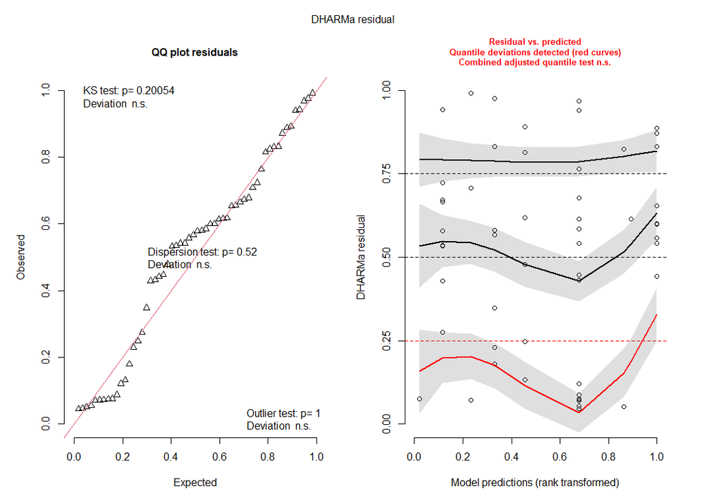

### Sires reproductive success for first reproductive event

```
> #sires
> #vgll3 additive sires NB
> mod1sires_dom1C <- glm.nb(n.offspring ~ vgll3_additive + vgll3_dominance + seaageatmaturity, link = log, data=Uts_conserved_total_RS_sires_1C)
> summary(mod1sires_dom1C)

Call:
glm.nb(formula = n.offspring ~ vgll3_additive + vgll3_dominance +
    seaageatmaturity, data = Uts_conserved_total_RS_sires_1C,
    link = log, init.theta = 0.8897868593)

Deviance Residuals:
    Min       1Q   Median       3Q      Max
-2.2606  -1.0932  -0.4851   0.2034   3.3064

Coefficients:
                 Estimate Std. Error z value Pr(>|z|)
(Intercept)       1.44598    0.21041   6.872 6.32e-12 ***
vgll3_additive   -0.04826    0.12862  -0.375    0.707
vgll3_dominance   0.19615    0.15907   1.233    0.218
seaageatmaturity  0.85098    0.10785   7.891 3.01e-15 ***
---
Signif. codes:  0 ‘***’ 0.001 ‘**’ 0.01 ‘*’ 0.05 ‘.’ 0.1 ‘ ’ 1

(Dispersion parameter for Negative Binomial(0.8898) family taken to be 1)

    Null deviance: 326.28  on 215  degrees of freedom
Residual deviance: 238.18  on 212  degrees of freedom
AIC: 1626.2

Number of Fisher Scoring iterations: 1


              Theta:  0.8898
          Std. Err.:  0.0829

 2 x log-likelihood:  -1616.1600
```

#### DHARMa residual plot: negative binomial with log link

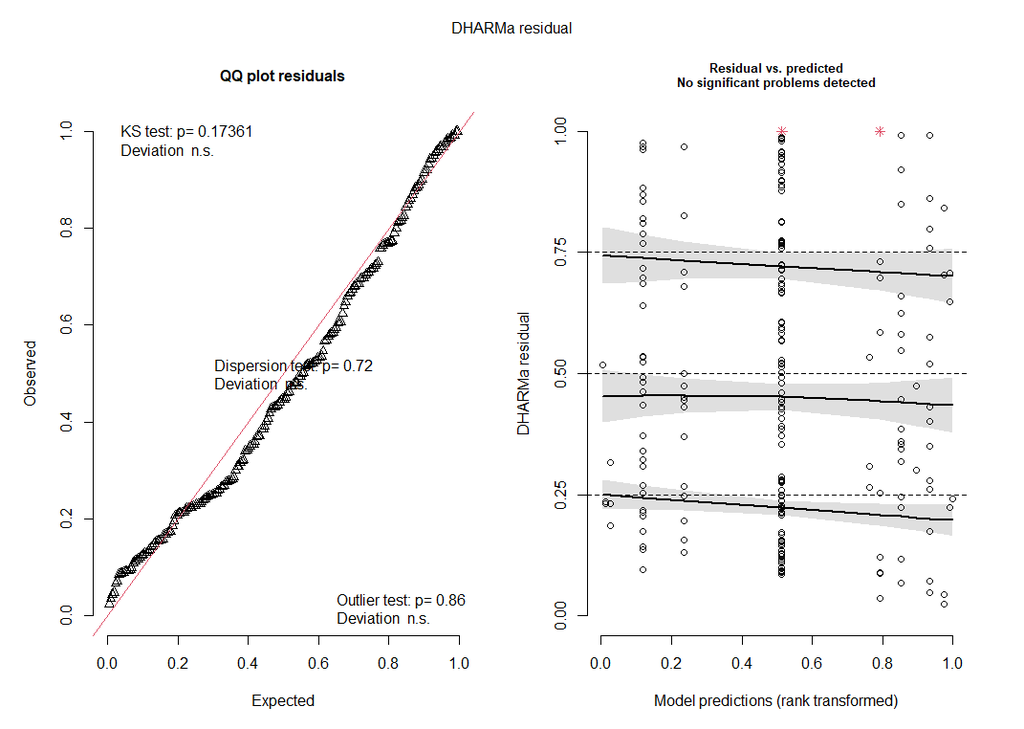

## Data analysis: additional information for revision

### Additional analyses for revisions

Rscript: `Revision information.R`

Dependent datafiles: `Data/UtsadultsALL_21.06.22.csv` `Data/Uts_cohort_SNP_cons_11.02.22.csv`

#### information concerning adult-adult samples, i.e. looking only at genotypes of individuals that were assigned as offspring that were sampled as adults

```
> #how many unique females mated?
> Uts_conserved_mated %>% filter(sex == "dam") %>% distinct(ID) %>% tally()
  n
1 56
> Utsadults %>% filter(sex == "F") %>% distinct(ID) %>% tally()
  n
1 93
> #how many females reproduced then captured?
> 56/93
[1] 0.6021505
> #how many adult to adult genotypes do we have in the dataset (all data)
> Uts_cohort_SNP_conserved %>% filter(Adult > 0) %>% count()
  n
1 50
> #what is the year range of adult to adult genotypes (all data)
> Uts_cohort_SNP_conserved %>% filter(Adult > 0) %>% group_by(year, c25_1441_SAC) %>% count()
# A tibble: 11 × 3
# Groups:   year, c25_1441_SAC [11]
   year c25_1441_SAC     n
  <int>        <int> <int>
1  2011            1     5
2  2011            2    11
3  2011            3     6
4  2012            1     1
5  2012            2     3
6  2012            3     3
7  2013            1     1
8  2013            2    13
9  2013            3     5
10  2014            2     1
11  2015            2     1
> #what is the number of offspring from adult to adult genotypes (all data)
> Uts_cohort_SNP_conserved %>% filter(Adult > 0) %>% tally(Adult)
  n
1 95
> #how many adult to adult to adult genotypes do we have in the restricted dataset
> Uts_conserved_mated %>% filter(Adult > 0) %>% count()
  n
1 45
> #what is the year range of adult to adult genotypes (all data)
> Uts_conserved_mated  %>% filter(Adult > 0 & type == "Adult") %>% group_by(year, c25_1441_SAC) %>% count()
# A tibble: 11 × 3
# Groups:   year, c25_1441_SAC [11]
   year c25_1441_SAC     n
  <int>        <int> <int>
1  2011            1     5
2  2011            2     9
3  2011            3     3
4  2012            1     1
5  2012            2     3
6  2012            3     3
7  2013            1     1
8  2013            2    13
9  2013            3     5
10  2014            2     1
11  2015            2     1
> #what is the number of offspring from adult to adult genotypes (all data)
> Uts_conserved_mated %>% filter(Adult > 0) %>% tally(Adult)
  n
1 78
```

#### how many offspring are in the different size classes and calculate the percentage

```
> #how many offspring are in the different size classes
> #0+
> Uts_cohort_SNP_conserved %>% tally(X0.)
    n
1 8068
> #1+
> Uts_cohort_SNP_conserved %>% tally(X1.)
    n
1 1680
> #2-3+
> Uts_cohort_SNP_conserved %>% tally(X2.3.)
   n
1 387
> #adult
> Uts_cohort_SNP_conserved %>% tally(Adult)
  n
1 95

#0+     8068    78.9%
#1+     1680    16.4%
#2-3+      387   3.8%
#adult    95     0.9%
#total 10230 100%
```

#### what does the distribution of vgll3 genotypes by year look like? Are there patterns?

dams

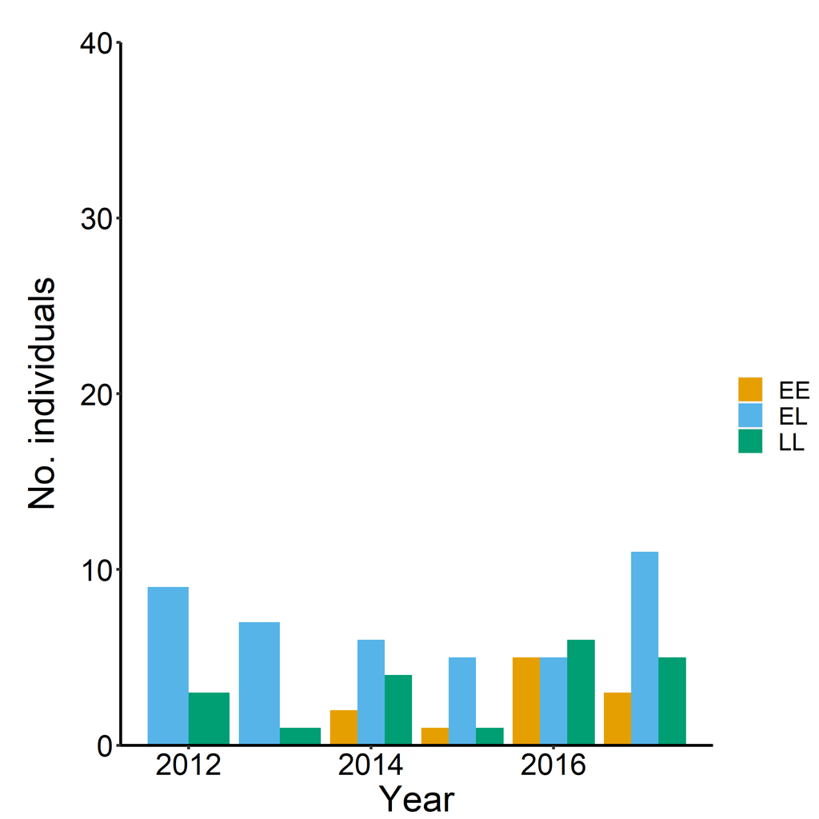

sires

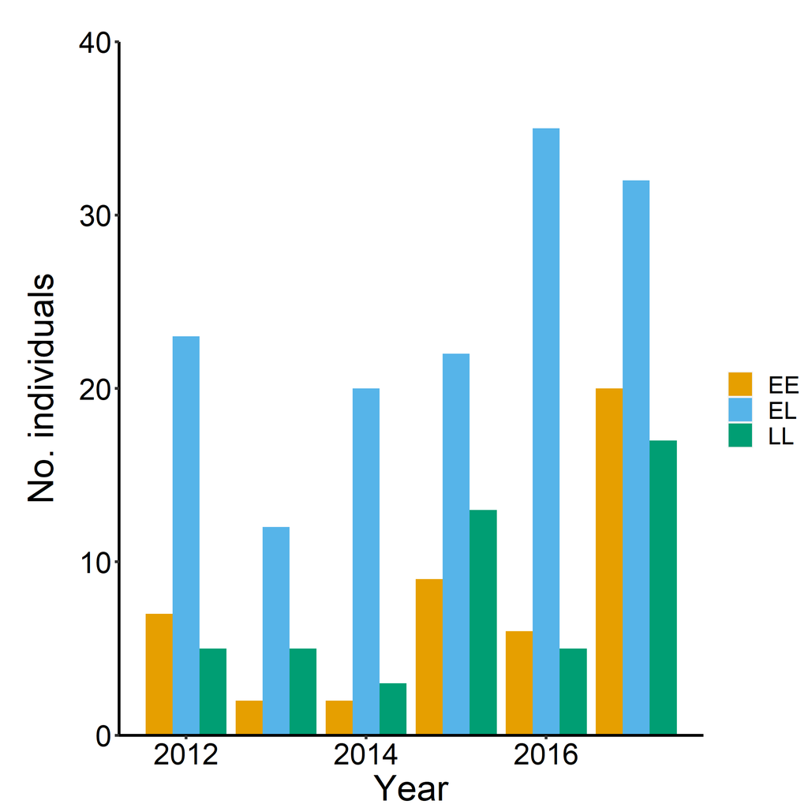